# VAR Predictability Benchmark

- Show All Code
- Hide All Code
- View Source

Results

Author

Affiliation

Björn S. Siepe

University of Marburg

Published

November 17, 2026

# 1 Preparation

```r
# fitted in 04_meta_regression.qmd
fit_m1 <- readRDS(here("output", "analysis", "fit_relmse_m1.rds"))
fit_m2 <- readRDS(here("output", "analysis", "fit_relmse_m2.rds"))
fit_m3 <- readRDS(here("output", "analysis", "fit_relmse_m3.rds"))
fit_s1 <- readRDS(here("output", "analysis", "fit_relmse_s1.rds"))
fit_s4 <- readRDS(here("output", "analysis", "fit_relmse_s4.rds"))

meta_order <- model_order[model_order != "mean"]
meta_labels <- model_labels[model_order != "mean"]

# one population-level coefficient per model and draw. "b_model" gives the location of log
# relative MSE and "b_sigma_model" the residual scale on the log link. a suffix such as
# ":log_n_within" selects the slope of that moderator instead
coef_draws <- function(fit, prefix, suffix = "") {
  posterior::as_draws_df(fit, variable = paste0("^", prefix, "[a-z_]+", suffix, "$"),
                         regex = TRUE) |>
    as_tibble() |>
    pivot_longer(starts_with(prefix), names_to = "model",
                 names_pattern = paste0(prefix, "([a-z_]+)", suffix), values_to = "value") |>
    select(.draw, model, value)
}

# posterior median and 95% equal-tailed interval
fmt_ci <- function(x) {
  sprintf("%.2f [%.2f, %.2f]", median(x), quantile(x, 0.025), quantile(x, 0.975))
}
```

# 2 Data and sample

## 2.1 Sample overview

```r
# sample and table_note are filled in by hand in the coding sheet
# sample falls back to the # openESM participants description while blank
registry <- readr::read_tsv(here("data", "meta", "datasets.tsv"),
                            col_types = readr::cols(dataset_id = readr::col_character()),
                            show_col_types = FALSE) |>
  mutate(dataset_id = sprintf("%04d", as.integer(dataset_id)))
for (col in c("sample", "table_note")) {
  if (!col %in% names(registry)) registry[[col]] <- NA_character_
}
# an empty column is read as logical
registry <- mutate(registry, across(c(sample, table_note, participants), as.character))
# written by scripts/export_references.R
citation_keys <- readr::read_tsv(here("output", "paper", "dataset_citation_keys.tsv"),
                                 col_types = "cc")

valid_obs <- combined |>
  distinct(dataset_id, id, n_valid_person) |>
  summarise(valid = sprintf("%g [%g, %g]", median(n_valid_person),
                            quantile(n_valid_person, 0.25), quantile(n_valid_person, 0.75)),
            .by = dataset_id)

datasets_tbl <- dataset_meta |>
  select(dataset_id, first_author, year, n_persons_kept, n_persons_excluded, n_items) |>
  left_join(select(registry, dataset_id, sample, participants, n_days, n_beeps_per_day, table_note),
            by = "dataset_id") |>
  left_join(citation_keys, by = "dataset_id") |>
  left_join(valid_obs, by = "dataset_id") |>
  arrange(first_author, year) |>
  mutate(label = paste0(first_author, " (", year, ")"),
         sample = coalesce(sample, participants, ""),
         table_note = na_if(trimws(table_note), ""),
         persons = sprintf("%s (%s)", n_persons_kept, n_persons_excluded),
         across(c(n_days, n_beeps_per_day), \(x) coalesce(as.character(x), "?")))

# datasets with the same note share a footnote letter
notes <- datasets_tbl |>
  filter(!is.na(table_note)) |>
  distinct(table_note) |>
  mutate(marker = letters[seq_len(n())])
datasets_tbl <- left_join(datasets_tbl, notes, by = "table_note")

datasets_tbl |>
  mutate(design = paste(n_days, "×", n_beeps_per_day),
         table_note = coalesce(table_note, "")) |>
  select(label, sample, design, persons, n_items, valid, table_note) |>
  knitr::kable(col.names = c("Dataset", "Sample", "Days × beeps per day", "Persons", "Items",
                             "Valid obs. per person", "Note"))
```

Table 1: Dataset overview. Persons: included (excluded). Valid observations are timepoints with complete responses and a usable lag, median [IQR] per person.

| Dataset | Sample | Days × beeps per day | Persons | Items | Valid obs. per person | Note |
| --- | --- | --- | --- | --- | --- | --- |
| Bosley (2019) | undergraduate students with elevated GAD symptoms | 19 × 4 | 22 (74) | 3 | 21 [20.25, 25.75] |  |
| Contreras (2020) | participants with above-average paranoid ideation and/or interpersonal sensitivity | 7 × 10 | 12 (11) | 5 | 25.5 [21.75, 29.5] |  |
| Drukker (2020) | individuals with IBS and panic disorder | 7 × 10 | 17 (7) | 8 | 43 [35, 47] |  |
| Fisher (2017) | participants with a diagnosis of MDD and/or GAD | 55 × 4 | 40 (0) | 21 | 76.5 [74, 87.25] |  |
| Fried (2021) | student sample | 14 × 4 | 50 (29) | 14 | 39 [37, 41] |  |
| Geschwind (2013) | individuals with residual depressive symptoms | 20 × 10 | 121 (9) | 6 | 79 [70, 91] |  |
| Grommisch (2020) | adults | 21 × 9 | 179 (0) | 4 | 149 [129.5, 163] |  |
| Kullar (2023) | participants with and without mood disorders | 14 × 5 | 98 (7) | 8 | 52 [45, 54] |  |
| Kuppens (2016) | undergraduate students | 7 × 10 | 93 (2) | 6 | 60 [56, 63] |  |
| Marian (2022) | undergraduate students | 21 × 3 | 31 (114) | 13 | 39 [37, 41] |  |
| Merolla (2022) | undergraduate students | 10 × 6 | 45 (75) | 2 | 24 [21, 29] |  |
| Nestler (2022) | unclear | 82 × 1 | 85 (0) | 6 | 78 [74, 80] |  |
| Neubauer (2020) | adults living in a household with a schoolchild | 21 × 1 | 70 (492) | 5 | 20 [20, 20] |  |
| Pavani (2017) | non-clinical individuals | 14 × 5 | 70 (8) | 7 | 39 [33, 47.75] |  |
| Reeves (2020) | participants with PTSD | 43 × 4 | 20 (0) | 17 | 77 [72.75, 82.25] |  |
| Rowland (2020) | undergraduate students | 40 × 6 | 125 (0) | 8 | 138 [109, 158] |  |
| Wang (2024) | young adults (18-25) | 21 × 7 | 67 (5) | 4 | 91 [77, 99] |  |
| Westhoff (2024) | young adults | 21 × 5 | 113 (0) | 6 | 78 [72, 81] |  |
| Wright (2019) | individuals with personality disorder diagnosis | 100 × 1 | 94 (0) | 5 | 90 [82, 94] |  |
| van Woerkom (2022) | Dutch working adults | 5 × 10 | 68 (105) | 15 | 31 [26.75, 36] |  |

Table 2

```r
# the paper version: a landscape table across pages with citations, footnote markers and the
# notes below. needs \usepackage{pdflscape, xltabular, booktabs}
escape_latex <- function(x) gsub("([&%$#_{}])", "\\\\\\1", x)

latex_rows <- datasets_tbl |>
  mutate(dataset = paste0(if_else(is.na(keys), label, paste0("\\textcite{", keys, "}")),
                          if_else(is.na(marker), "", paste0("\\textsuperscript{", marker, "}"))),
         design = paste(n_days, "$\\times$", n_beeps_per_day),
         sample = escape_latex(sample)) |>
  select(dataset, sample, design, persons, n_items, valid)
# paste0 would turn zero notes into one empty marker
latex_notes <- if (nrow(notes) > 0) {
  paste0("\\textsuperscript{", notes$marker, "}", escape_latex(notes$table_note), collapse = " ")
} else {
  ""
}

# sample is an X column, so it wraps instead of running off the page.
# the header repeats on every page
header <- c("\\toprule",
            "Dataset & Sample & Design & Persons & Items & Valid obs. \\\\",
            "\\midrule")
latex_table <- c(
  "\\begin{landscape}",
  "\\small",
  "\\renewcommand{\\arraystretch}{1.2}",
  paste0("\\begin{xltabular}{\\linewidth}{@{}>{\\raggedright\\arraybackslash}p{7.5cm} ",
         ">{\\raggedright\\arraybackslash}X l r r l@{}}"),
  "\\caption{Overview of Datasets}",
  "\\label{tab:datasets} \\\\",
  header,
  "\\endfirsthead",
  header,
  "\\endhead",
  "\\bottomrule",
  "\\endfoot",
  paste(do.call(paste, c(latex_rows, sep = " & ")), "\\\\"),
  "\\end{xltabular}",
  "",
  paste("\\noindent \\textit{Note.} Persons: included (excluded).",
        "Design: days $\\times$ beeps per day.",
        "Valid obs.: timepoints with complete responses and a usable lag, median [IQR] per person.",
        latex_notes),
  "\\end{landscape}"
)
writeLines(latex_table, here("output", "paper", "tbl_datasets.tex"))
```

Overall dataset and person counts, before and after exclusions. `n_total_person` counts the number of scheduled beeps per person, in case information about the number of scheduled beeps is available. Only beeps from a person’s first to last recorded day are counted, as scheduled days outside this span are unknown, so it may still underestimate the full schedule. It is used as a proxy for series length, not as a compliance measure.

```r
combined |>
  distinct(dataset_id, id, n_valid_person, n_total_person) |>
  summarise(datasets = n_distinct(dataset_id), persons = n(),
            valid_obs = sum(n_valid_person), rows = sum(n_total_person)) |>
  mutate(persons_before_exclusion = sum(dataset_meta$n_persons_kept +
                                          dataset_meta$n_persons_excluded))
```

```
# A tibble: 1 × 5
  datasets persons valid_obs   rows persons_before_exclusion
     <int>   <int>     <int>  <int>                    <int>
1       20    1420    107227 162052                     2358
```

## 2.2 Exclusions

```r
dataset_meta |>
  arrange(first_author, year) |>
  mutate(dataset = paste0(first_author, " (", year, ")")) |>
  select(dataset, n_persons_kept, n_excluded_low_obs, n_excluded_zero_var) |>
  knitr::kable(col.names = c("Dataset", "Included", "Excluded: too few valid obs.",
                             "Excluded: zero variance"))
```

Table 3: Persons included and excluded per dataset, by reason.

| Dataset | Included | Excluded: too few valid obs. | Excluded: zero variance |
| --- | --- | --- | --- |
| Bosley (2019) | 22 | 74 | 0 |
| Contreras (2020) | 12 | 10 | 1 |
| Drukker (2020) | 17 | 2 | 5 |
| Fisher (2017) | 40 | 0 | 0 |
| Fried (2021) | 50 | 4 | 25 |
| Geschwind (2013) | 121 | 2 | 7 |
| Grommisch (2020) | 179 | 0 | 0 |
| Kullar (2023) | 98 | 0 | 7 |
| Kuppens (2016) | 93 | 0 | 2 |
| Marian (2022) | 31 | 4 | 110 |
| Merolla (2022) | 45 | 74 | 1 |
| Nestler (2022) | 85 | 0 | 0 |
| Neubauer (2020) | 70 | 490 | 2 |
| Pavani (2017) | 70 | 1 | 7 |
| Reeves (2020) | 20 | 0 | 0 |
| Rowland (2020) | 125 | 0 | 0 |
| Wang (2024) | 67 | 1 | 4 |
| Westhoff (2024) | 113 | 0 | 0 |
| Wright (2019) | 94 | 0 | 0 |
| van Woerkom (2022) | 68 | 57 | 48 |

# 3 Estimation diagnostics

## 3.1 Estimation summary

```r
# each model raises at most one of these types, so they share a column
issue_types <- c("rank_deficient", "lasso_boundary", "singular")

issue_summary <- fit_issues |>
  mutate(type = if_else(type %in% issue_types, "issue", type)) |>
  summarise(n = sum(n), .by = c(dataset_id, model, n_fits, type)) |>
  summarise(issue_pct = 100 * sum(n[type == "issue"]) / sum(n_fits[type == "issue"]),
            issue_datasets = n_distinct(dataset_id[type == "issue" & n > 0]),
            convergence_per_100 = 100 * sum(n[type == "convergence"]) /
              sum(n_fits[type == "convergence"]),
            other = sum(n[type == "other"]),
            .by = model)

failures <- dataset_meta |>
  mutate(model = lapply(model_failures, names)) |>
  select(dataset_id, model, failed = model_failures) |>
  unnest(c(model, failed)) |>
  summarise(failed = sum(failed), .by = model)

undefined_rel_mse <- rel_mse_drops |>
  filter(set == "oos") |>
  summarise(undefined = sum(n), .by = model)

time_summary <- fit_times |>
  summarise(cpu_h = sum(cpu_sec) / 3600, .by = model) |>
  mutate(cpu_pct = 100 * cpu_h / sum(cpu_h))

failures |>
  left_join(issue_summary, by = "model") |>
  left_join(undefined_rel_mse, by = "model") |>
  left_join(time_summary, by = "model") |>
  mutate(undefined = coalesce(undefined, 0L),
         model = factor(model, levels = model_order, labels = model_labels)) |>
  arrange(model) |>
  select(model, failed, issue_pct, issue_datasets, convergence_per_100, other, undefined,
         cpu_h, cpu_pct) |>
  knitr::kable(digits = 1, col.names = c("Model", "Failed datasets", "Issue (% of fits)",
                                         "Datasets with issue", "Convergence warnings",
                                         "Other warnings", "Persons without relative MSE",
                                         "CPU time (h)", "CPU time (%)"))
```

Table 4: Estimation issues and computation time per model, pooled across datasets. Issue: rank-deficient fits (AR, VAR), boundary fits (LASSO VAR) or singular fits (RI, mlAR, mlVAR), as a share of all fits. Convergence warnings are counted per 100 lmer fits. Persons without relative MSE are OOS person-model combinations.

| Model | Failed datasets | Issue (% of fits) | Datasets with issue | Convergence warnings | Other warnings | Persons without relative MSE | CPU time (h) | CPU time (%) |
| --- | --- | --- | --- | --- | --- | --- | --- | --- |
| Mean | 0 | 0.0 | 0 | 0.0 | 0 | 4 | 0.0 | 0.1 |
| Naive | 0 | 0.0 | 0 | 0.0 | 0 | 293 | 0.0 | 0.1 |
| Trend | 0 | 0.0 | 0 | 0.0 | 0 | 4 | 0.0 | 0.1 |
| RI | 0 | 3.1 | 1 | 0.0 | 0 | 4 | 0.2 | 6.5 |
| AR | 0 | 2.0 | 10 | 0.0 | 0 | 12 | 0.0 | 0.1 |
| VAR | 0 | 2.7 | 10 | 0.0 | 0 | 9 | 0.0 | 0.1 |
| LASSO VAR | 0 | 19.5 | 20 | 0.0 | 0 | 4 | 0.0 | 1.5 |
| mlAR | 0 | 5.0 | 7 | 0.7 | 7 | 4 | 0.4 | 12.1 |
| mlVAR | 0 | 78.9 | 19 | 0.2 | 3 | 4 | 2.4 | 79.4 |

```r
lasso_mean_oos <- filter(lasso_mean, set == "oos")

tibble(datasets = nrow(dataset_meta),
       cpu_total_h = sum(fit_times$cpu_sec) / 3600,
       ml_var_cpu_pct = 100 * sum(fit_times$cpu_sec[fit_times$model == "ml_var"]) /
         sum(fit_times$cpu_sec),
       ml_var_uncorrelated = sum(dataset_meta$ml_var_uncorrelated, na.rm = TRUE),
       lasso_equals_mean_pct = 100 * weighted.mean(lasso_mean_oos$share_equals_mean,
                                                   lasso_mean_oos$n_predictions),
       machines = n_distinct(fit_times$cpu))
```

```
# A tibble: 1 × 6
  datasets cpu_total_h ml_var_cpu_pct ml_var_uncorrelated lasso_equals_mean_pct
     <int>       <dbl>          <dbl>               <int>                 <dbl>
1       20        3.00           79.4                   5                  46.3
# ℹ 1 more variable: machines <int>
```

## 3.2 Summary for the manuscript

The following paragraph gives the numbers reported in the estimation diagnostics of the manuscript. CPU time is the sum over all fits of all models and datasets, including every refit of the rolling-origin evaluation. It adds up the time of all cores, so it is longer than the elapsed time of the parallel run. A relMSE is undefined for a person and a model if the model or the person mean predicts all test values of an item exactly, or if an item has no scored predictions. The counts refer to person-model combinations out of sample, excluding the mean model, whose relMSE is 1 by construction. Singular fits and rank-deficient fits are counted as shares of all fits of a model in a dataset, as in the tables above.

```r
reason_labels <- c(zero_model = "the model predicted all test values of an item exactly",
                   zero_reference = "the person mean predicted all test values of an item exactly",
                   missing = "an item had no scored predictions")

n_datasets <- nrow(dataset_meta)
n_persons <- nrow(distinct(combined, dataset_id, id))
n_failed_fits <- sum(unlist(dataset_meta$model_failures))

person_models <- filter(combined, set == "oos", model != "mean")
undefined <- filter(person_models, !is.finite(rel_mse))
undefined_by_model <- count(undefined, model = as.character(model), sort = TRUE)
undefined_by_reason <- count(undefined, reason_na, sort = TRUE)
stopifnot(all(undefined$reason_na %in% names(reason_labels)))

issue_shares <- function(m, issue) {
  fit_issues |>
    filter(model == m, type == issue) |>
    mutate(share = n / n_fits) |>
    pull(share)
}
ml_var_singular <- issue_shares("ml_var", "singular")
var_rank_deficient <- issue_shares("var", "rank_deficient")
stopifnot(length(ml_var_singular) == n_datasets, length(var_rank_deficient) == n_datasets)
```

Fitting all models took 180 CPU minutes in total, on AMD Ryzen Threadripper 3970X 32-Core Processor. Of the 180 combinations of 9 models and 20 datasets, 0 failed to produce predictions. For 334 of the 11360 person-model combinations (2.9%), no relMSE was defined, affecting 293 of 1420 persons for at least one model. Most of these combinations concerned Naive (293), and the most frequent reason was that the model predicted all test values of an item exactly (302). For mlVAR, at least 50% of the fits were singular in 16 of 20 datasets. Rank-deficient VAR fits occurred in 10 of 20 datasets, with a median share of 4.0% of fits in these datasets.

## 3.3 Non-Convergence

```r
ols_models <- c("ar", "var")
ml_models <- c("ri", "ml_ar", "ml_var")

# share of affected fits for one issue type, one column per model
issue_share <- function(models, issue, labels, prefix) {
  fit_issues |>
    filter(model %in% models, type == issue) |>
    mutate(share = sprintf("%.0f%%", 100 * n / n_fits),
           model = paste(prefix, factor(model, levels = models, labels = labels))) |>
    select(dataset_id, model, share) |>
    pivot_wider(names_from = model, values_from = share)
}

rank_deficient <- issue_share(ols_models, "rank_deficient", c("AR", "VAR"), "Rank-deficient:")
lasso_boundary <- issue_share("lasso_var", "lasso_boundary", "LASSO VAR", "Boundary:")
singular <- issue_share(ml_models, "singular", c("RI", "mlAR", "mlVAR"), "Singular:")

lasso_equals_mean <- lasso_mean |>
  filter(set == "oos") |>
  mutate(`LASSO VAR equal to mean` = sprintf("%.0f%%", 100 * share_equals_mean)) |>
  select(dataset_id, `LASSO VAR equal to mean`)

other_issues <- fit_issues |>
  summarise(`Convergence warnings` = sum(n[type == "convergence"]),
            `Other warnings` = sum(n[type == "other"]), .by = dataset_id)

failed <- dataset_meta |>
  mutate(failed = vapply(model_failures, function(f) {
    paste(model_labels[match(names(f)[f], model_order)], collapse = ", ")
  }, character(1))) |>
  select(dataset_id, first_author, year, failed, ml_var_uncorrelated)

failed |>
  left_join(rank_deficient, by = "dataset_id") |>
  left_join(lasso_boundary, by = "dataset_id") |>
  left_join(lasso_equals_mean, by = "dataset_id") |>
  left_join(singular, by = "dataset_id") |>
  left_join(other_issues, by = "dataset_id") |>
  arrange(first_author, year) |>
  mutate(Dataset = paste0(first_author, " (", year, ")"),
         `Failed models` = failed,
         `mlVAR uncorrelated RE` = if_else(ml_var_uncorrelated, "yes", "no")) |>
  select(Dataset, starts_with("Rank-deficient"), starts_with("Boundary"),
         `LASSO VAR equal to mean`, starts_with("Singular"),
         `Convergence warnings`, `Other warnings`, `Failed models`, `mlVAR uncorrelated RE`) |>
  knitr::kable()
```

Table 5: Estimation issues per dataset. Rank-deficient fits are the share of person-level OLS fits with aliased coefficients (set to 0). LASSO VAR boundary fits are the share of fits in which at least one equation selects the smallest admissible lambda (end of the lambda path or the df cap). LASSO VAR equal to mean is the share of OOS predictions identical to the mean model’s, an upper bound on the share of empty selections. Singular fits are the share of lmer fits (one per item and fit step). Convergence and other warnings are counts of warnings.

| Dataset | Rank-deficient: AR | Rank-deficient: VAR | Boundary: LASSO VAR | LASSO VAR equal to mean | Singular: RI | Singular: mlAR | Singular: mlVAR | Convergence warnings | Other warnings | Failed models | mlVAR uncorrelated RE |
| --- | --- | --- | --- | --- | --- | --- | --- | --- | --- | --- | --- |
| Bosley (2019) | 0% | 0% | 32% | 50% | 0% | 18% | 58% | 2 | 0 |  | no |
| Contreras (2020) | 8% | 8% | 24% | 49% | 0% | 25% | 91% | 0 | 0 |  | no |
| Drukker (2020) | 1% | 4% | 14% | 53% | 0% | 0% | 91% | 0 | 0 |  | no |
| Fisher (2017) | 0% | 0% | 4% | 34% | 0% | 0% | 97% | 1 | 0 |  | yes |
| Fried (2021) | 9% | 20% | 25% | 54% | 0% | 1% | 100% | 0 | 0 |  | yes |
| Geschwind (2013) | 1% | 1% | 21% | 37% | 0% | 0% | 50% | 0 | 0 |  | no |
| Grommisch (2020) | 0% | 0% | 36% | 34% | 0% | 0% | 2% | 0 | 0 |  | no |
| Kullar (2023) | 4% | 4% | 7% | 58% | 0% | 0% | 78% | 1 | 0 |  | no |
| Kuppens (2016) | 0% | 0% | 12% | 58% | 0% | 0% | 76% | 1 | 0 |  | no |
| Marian (2022) | 15% | 16% | 27% | 35% | 0% | 0% | 99% | 0 | 0 |  | yes |
| Merolla (2022) | 1% | 1% | 23% | 69% | 0% | 0% | 23% | 4 | 3 |  | no |
| Nestler (2022) | 0% | 0% | 2% | 75% | 83% | 71% | 86% | 7 | 7 |  | no |
| Neubauer (2020) | 2% | 2% | 35% | 57% | 0% | 16% | 58% | 0 | 0 |  | no |
| Pavani (2017) | 4% | 4% | 12% | 51% | 0% | 0% | 64% | 0 | 0 |  | no |
| Reeves (2020) | 0% | 0% | 10% | 47% | 0% | 1% | 98% | 1 | 0 |  | yes |
| Rowland (2020) | 0% | 0% | 18% | 29% | 0% | 0% | 60% | 0 | 0 |  | no |
| Wang (2024) | 0% | 0% | 25% | 41% | 0% | 0% | 0% | 0 | 0 |  | no |
| Westhoff (2024) | 0% | 0% | 13% | 49% | 0% | 0% | 58% | 0 | 0 |  | no |
| Wright (2019) | 0% | 0% | 9% | 53% | 0% | 0% | 20% | 0 | 0 |  | no |
| van Woerkom (2022) | 11% | 18% | 36% | 45% | 0% | 7% | 99% | 0 | 0 |  | yes |

## 3.4 Undefined relative MSE

```r
drops <- rel_mse_drops |>
  filter(set == "oos") |>
  mutate(model = as.character(model))

# rel_mse_drops only holds nonzero counts, so a model that ran but is absent dropped no one.
# models that failed for a dataset have no persons at all and stay NA
ran <- combined |>
  filter(set == "oos") |>
  distinct(dataset_id, model = as.character(model))

drops |>
  distinct(dataset_id, reason_na) |>
  inner_join(ran, by = "dataset_id", relationship = "many-to-many") |>
  left_join(select(drops, dataset_id, model, reason_na, n),
            by = c("dataset_id", "model", "reason_na")) |>
  mutate(n = coalesce(n, 0L)) |>
  left_join(dataset_labels, by = "dataset_id") |>
  mutate(model = factor(model, levels = model_order, labels = model_labels)) |>
  arrange(model) |>
  # every model gets a column, also one that failed in all datasets listed here
  pivot_wider(id_cols = c(dataset, reason_na), names_from = model, values_from = n,
              names_expand = TRUE) |>
  mutate(across(-c(dataset, reason_na), \(x) if_else(is.na(x), "–", as.character(x)))) |>
  arrange(dataset, reason_na) |>
  rename(Dataset = dataset, Reason = reason_na) |>
  knitr::kable()
```

Table 6: Persons without a defined OOS relative MSE, per dataset, reason and model. zero_model: the model predicts an item exactly. zero_reference: the mean model predicts an item exactly. missing: an item has no scored predictions. Persons are excluded only for the affected model. –: the model failed for the dataset.

| Dataset | Reason | Mean | Naive | Trend | RI | AR | VAR | LASSO VAR | mlAR | mlVAR |
| --- | --- | --- | --- | --- | --- | --- | --- | --- | --- | --- |
| Contreras (2020) | zero_model | 0 | 4 | 0 | 0 | 0 | 0 | 0 | 0 | 0 |
| Drukker (2020) | zero_model | 0 | 7 | 0 | 0 | 0 | 0 | 0 | 0 | 0 |
| Drukker (2020) | zero_reference | 1 | 1 | 1 | 1 | 1 | 1 | 1 | 1 | 1 |
| Fisher (2017) | zero_model | 0 | 2 | 0 | 0 | 0 | 0 | 0 | 0 | 0 |
| Fried (2021) | zero_model | 0 | 28 | 0 | 0 | 1 | 1 | 0 | 0 | 0 |
| Geschwind (2013) | zero_model | 0 | 55 | 0 | 0 | 0 | 0 | 0 | 0 | 0 |
| Grommisch (2020) | zero_model | 0 | 15 | 0 | 0 | 0 | 0 | 0 | 0 | 0 |
| Kullar (2023) | zero_model | 0 | 46 | 0 | 0 | 0 | 0 | 0 | 0 | 0 |
| Kuppens (2016) | zero_model | 0 | 10 | 0 | 0 | 0 | 0 | 0 | 0 | 0 |
| Marian (2022) | zero_model | 0 | 22 | 0 | 0 | 2 | 2 | 0 | 0 | 0 |
| Merolla (2022) | zero_model | 0 | 1 | 0 | 0 | 0 | 0 | 0 | 0 | 0 |
| Nestler (2022) | zero_model | 0 | 11 | 0 | 0 | 0 | 0 | 0 | 0 | 0 |
| Neubauer (2020) | zero_model | 0 | 6 | 0 | 0 | 0 | 0 | 0 | 0 | 0 |
| Pavani (2017) | zero_model | 0 | 24 | 0 | 0 | 2 | 1 | 0 | 0 | 0 |
| Reeves (2020) | zero_model | 0 | 3 | 0 | 0 | 0 | 0 | 0 | 0 | 0 |
| Rowland (2020) | zero_model | 0 | 8 | 0 | 0 | 0 | 0 | 0 | 0 | 0 |
| Wang (2024) | zero_model | 0 | 13 | 0 | 0 | 0 | 0 | 0 | 0 | 0 |
| Westhoff (2024) | zero_model | 0 | 4 | 0 | 0 | 0 | 0 | 0 | 0 | 0 |
| Wright (2019) | zero_model | 0 | 12 | 0 | 0 | 0 | 0 | 0 | 0 | 0 |
| van Woerkom (2022) | zero_model | 0 | 18 | 0 | 0 | 3 | 1 | 0 | 0 | 0 |
| van Woerkom (2022) | zero_reference | 3 | 3 | 3 | 3 | 3 | 3 | 3 | 3 | 3 |

## 3.5 Out-of-Scale Predictions

```r
features$oos |>
  filter(model %in% c("ar", "var")) |>
  summarise(share_outside = mean(yhat < -0.5 | yhat > 1.5), max_abs = max(abs(yhat)),
            .by = c(dataset_id, model)) |>
  filter(share_outside > 0) |>
  left_join(select(dataset_meta, dataset_id, first_author, year), by = "dataset_id") |>
  mutate(dataset = paste0(first_author, " (", year, ")"),
         model = factor(model, levels = model_order, labels = model_labels),
         share_outside = sprintf("%.2f%%", 100 * share_outside)) |>
  arrange(desc(max_abs)) |>
  select(dataset, model, share_outside, max_abs) |>
  knitr::kable(digits = 1, col.names = c("Dataset", "Model", "Share of predictions",
                                         "Largest |prediction|"))
```

Table 7: AR and VAR predictions more than half a scale width outside [0, 1], per dataset. Datasets without such predictions are omitted.

| Dataset | Model | Share of predictions | Largest \|prediction\| |
| --- | --- | --- | --- |
| van Woerkom (2022) | VAR | 3.47% | 38.5 |
| Westhoff (2024) | VAR | 0.01% | 3.5 |
| Fried (2021) | VAR | 1.23% | 3.4 |
| Geschwind (2013) | VAR | 0.06% | 2.6 |
| Marian (2022) | VAR | 1.61% | 2.4 |
| Contreras (2020) | VAR | 0.50% | 2.2 |
| Grommisch (2020) | VAR | 0.01% | 2.2 |
| Kullar (2023) | VAR | 0.09% | 1.8 |
| Wang (2024) | VAR | 0.11% | 1.7 |
| Reeves (2020) | VAR | 0.06% | 1.7 |
| Neubauer (2020) | VAR | 0.03% | 1.4 |
| Fisher (2017) | VAR | 0.07% | 1.4 |
| Pavani (2017) | VAR | 0.06% | 1.3 |
| Drukker (2020) | VAR | 0.07% | 1.2 |

## 3.6 Computation Times

```r
# times are only comparable between models run on the same machine
unique(fit_times$cpu)
```

```
[1] "AMD Ryzen Threadripper 3970X 32-Core Processor"
```

# 4 Predictive accuracy across models and datasets

## 4.1 Overall performance

```r
fmt_median_iqr <- function(x, digits) {
  sprintf(paste0("%.", digits, "f [%.", digits, "f, %.", digits, "f]"),
          median(x), quantile(x, 0.25), quantile(x, 0.75))
}

rmse_summary <- combined |>
  filter(set == "oos", is.finite(rmse)) |>
  summarise(rmse = fmt_median_iqr(100 * rmse, 1), .by = model) |>
  mutate(model = as.character(model))

# paired: a person enters a model's relMSE columns only if that model's relMSE is defined both
# in-sample and out-of-sample
rel_mse_pairs <- combined |>
  filter(set %in% c("in", "oos")) |>
  mutate(model = as.character(model)) |>
  select(dataset_id, id, model, set, rel_mse) |>
  pivot_wider(names_from = set, values_from = rel_mse) |>
  filter(is.finite(`in`), is.finite(oos))

# the numeric medians come first, before oos and in are overwritten by their formatted versions
rel_mse_summary <- rel_mse_pairs |>
  summarise(oos_median = median(oos), is_median = median(`in`),
            oos = fmt_median_iqr(oos, 2), is = fmt_median_iqr(`in`, 2), n = n(), .by = model)

performance <- tibble(model = model_order) |>
  left_join(rmse_summary, by = "model") |>
  left_join(rel_mse_summary, by = "model") |>
  # the mean model is the reference, so its relMSE is 1 by construction
  mutate(across(c(oos, is), \(x) if_else(model == "mean", "1 (reference)", x)),
         across(c(oos_median, is_median), \(x) if_else(model == "mean", NA_real_, x)))

performance |>
  mutate(model = factor(model, levels = model_order, labels = model_labels)) |>
  select(model, rmse, oos, is) |>
  knitr::kable(col.names = c("Model", "RMSE (scale points)", "relMSE, out-of-sample",
                             "relMSE, in-sample"))
```

Table 8: Predictive performance per model, median [IQR] across persons. RMSE: OOS root mean squared error pooled over items, in points of the scale range (items rescaled to [0, 1] and multiplied by 100). relMSE: MSE relative to the mean model, out-of-sample and in-sample. In-sample values come from models fitted to all valid observations and are relative to the in-sample mean model. For each model, both relMSE columns use the same persons: those whose relMSE for that model is defined both in-sample and out-of-sample. RMSE is descriptive, models are compared with relMSE.

| Model | RMSE (scale points) | relMSE, out-of-sample | relMSE, in-sample |
| --- | --- | --- | --- |
| Mean | 17.1 [12.8, 21.9] | 1 (reference) | 1 (reference) |
| Naive | 19.3 [14.3, 25.2] | 1.27 [0.95, 1.60] | 1.51 [1.30, 1.70] |
| Trend | 17.0 [12.6, 21.9] | 0.98 [0.79, 1.15] | 0.94 [0.90, 0.97] |
| RI | 17.1 [12.8, 21.9] | 1.00 [1.00, 1.03] | 1.00 [1.00, 1.00] |
| AR | 16.3 [12.2, 20.9] | 0.92 [0.80, 1.00] | 0.91 [0.84, 0.95] |
| VAR | 17.8 [12.9, 23.5] | 1.06 [0.87, 1.35] | 0.78 [0.65, 0.87] |
| LASSO VAR | 16.6 [12.4, 21.5] | 0.98 [0.85, 1.03] | 0.88 [0.78, 0.95] |
| mlAR | 16.1 [12.1, 20.7] | 0.92 [0.81, 1.00] | 0.92 [0.86, 0.96] |
| mlVAR | 16.0 [12.0, 20.5] | 0.92 [0.79, 1.03] | 0.87 [0.79, 0.93] |

To compare in-sample and out-of-sample performance, we determine for each person the model with the lowest relMSE, once in-sample and once out-of-sample. This uses only persons for whom every model has a defined relMSE, both in-sample and out-of-sample, so that every person can choose among the same models. If two models have exactly the same relMSE, the simpler one counts as best, in the order of the model list (e.g. the mean model over a LASSO VAR that selects no lags). The median relMSE ranges below leave out the mean model, whose relMSE is 1 by construction.

```r
best_model <- combined |>
  filter(set %in% c("in", "oos"), is.finite(rel_mse)) |>
  mutate(model = as.character(model)) |>
  filter(n_distinct(model, set) == 2 * length(model_order), .by = c(dataset_id, id)) |>
  arrange(rel_mse, match(model, model_order)) |>
  slice_head(n = 1, by = c(dataset_id, id, set)) |>
  select(dataset_id, id, set, model) |>
  pivot_wider(names_from = set, values_from = model)

best_share <- best_model |>
  pivot_longer(c(`in`, oos), names_to = "set", values_to = "model") |>
  count(set, model) |>
  complete(set, model = model_order, fill = list(n = 0)) |>
  mutate(pct = 100 * n / sum(n), .by = set)

pct_best <- function(m, s) best_share$pct[best_share$model == m & best_share$set == s]
top_best <- function(s) {
  top <- slice_max(filter(best_share, set == s), pct, n = 1, with_ties = FALSE)
  sprintf("%s (%.0f%%)", model_labels[match(top$model, model_order)], top$pct)
}

non_mean <- filter(rel_mse_summary, model != "mean")
fmt_range <- function(x) sprintf("%.2f to %.2f", min(x), max(x))
```

The median in-sample relMSE ranged from 0.78 to 1.51 across models, and the median out-of-sample relMSE from 0.92 to 1.27. For 1126 of 1420 persons, every model had a defined relMSE both in-sample and out-of-sample. Among them, the model with the lowest in-sample relMSE also had the lowest out-of-sample relMSE for 8.6% of persons. The most frequent best model was VAR (96%) in-sample and Trend (25%) out-of-sample. VAR was the best model for 96.3% of persons in-sample and for 6.4% out-of-sample.

Table 9

```r
# the paper version, with the model names and groups of the model overview table.
# needs booktabs and \usepackage[table]{xcolor}
paper_model_names <- c(mean = "Person mean", naive = "Naïve persistence", trend = "Linear trend",
                       ri = "Random intercept", ar = "Idiographic AR(1)",
                       var = "Idiographic VAR(1)", lasso_var = "Regularized idiographic VAR(1)",
                       ml_ar = "Multilevel AR(1)", ml_var = "Multilevel VAR(1)")
model_groups <- list("Models without dynamics" = c("mean", "ri", "trend"),
                     "Naïve baseline" = "naive",
                     "Dynamic models" = c("ar", "ml_ar", "var", "lasso_var", "ml_var"))
stopifnot(setequal(names(paper_model_names), model_order),
          setequal(unlist(model_groups), model_order))

# blue below 1, red above 1 (the RdBu ends of the dominance figure). the tint grows with the
# distance of the median from 1 on the log scale, up to a factor of 1.5
cell_shade <- function(median_value) {
  vapply(median_value, function(m) {
    if (is.na(m)) return("")
    strength <- min(abs(log(m)) / log(1.5), 1)
    sprintf("\\cellcolor{%s!%d}", if (m < 1) "relmseLower" else "relmseHigher",
            round(5 + 35 * strength))
  }, character(1))
}

performance_rows <- unlist(lapply(seq_along(model_groups), function(g) {
  group <- performance[match(model_groups[[g]], performance$model), ]
  c(if (g > 1) "\\addlinespace[0.3em]",
    paste0("\\multicolumn{4}{@{}l}{\\textit{", names(model_groups)[g], "}} \\\\"),
    sprintf("\\quad %s & %s & %s%s & %s%s \\\\", paper_model_names[group$model], group$rmse,
            cell_shade(group$oos_median), group$oos, cell_shade(group$is_median), group$is))
}))

performance_tex <- c(
  "\\begin{table}[ht]",
  "\\centering",
  "\\caption{Predictive Performance of All Models}",
  "\\label{tab:performance}",
  "\\small",
  "\\definecolor{relmseLower}{HTML}{2166AC}",
  "\\definecolor{relmseHigher}{HTML}{B2182B}",
  # no @{} on the right: \cellcolor fills the column padding, so the rules must include it
  "\\begin{tabular}{@{}lrrr}",
  "\\toprule",
  " & RMSE & \\multicolumn{2}{c}{relMSE} \\\\",
  "\\cmidrule(l){3-4}",
  "Model & (scale points) & Out-of-sample & In-sample \\\\",
  "\\midrule",
  performance_rows,
  "\\bottomrule",
  "\\end{tabular}",
  "",
  "\\vspace{0.4em}",
  paste("\\noindent \\raggedright \\textit{Note.} Median [IQR] across persons. RMSE:",
        "out-of-sample root mean squared error, pooled over items, in points of the scale range",
        "(items rescaled to [0, 100]). relMSE: mean squared error relative to the person mean",
        "model. In-sample values are based on models fitted to all valid observations, relative",
        "to the in-sample person mean. For each model, both relMSE columns are based on the same",
        "individuals whose relMSE is defined both in-sample and out-of-sample",
        sprintf("(%d to %d persons, depending on the model).",
                min(rel_mse_summary$n), max(rel_mse_summary$n)),
        "Shading: blue for a median relMSE below 1, red above 1, darker for larger deviations."),
  "\\end{table}"
)
writeLines(performance_tex, here("output", "paper", "tbl_performance.tex"))
```

## 4.2 Relative MSE across datasets

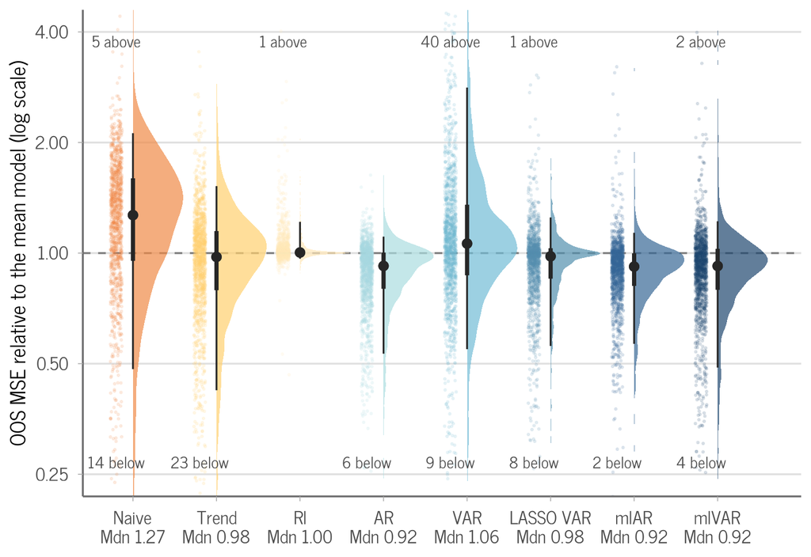

Figure 1: Out-of-sample MSE relative to the mean model by model complexity. Points are persons. Distributions show the median with 50% and 90% intervals. Values below 1 mean lower error than the mean model.

```r
# the mean model is the reference with rel_mse = 1 by construction, so it is not shown
is_reference <- model_order == "mean"

dat_rel <- combined |>
  filter(set == "oos", model != "mean", is.finite(rel_mse)) |>
  mutate(model = factor(model, levels = model_order[!is_reference],
                        labels = model_labels[!is_reference]),
         # persons are drawn left of the distribution
         x_points = as.numeric(model) - 0.2)

# symmetric around 1 on the log axis
rel_lim <- c(0.25, 4)

rel_beyond <- dat_rel |>
  summarise(n_below = sum(rel_mse < rel_lim[1]), n_above = sum(rel_mse > rel_lim[2]),
            .by = model)

# medians in the axis labels, so the panel stays free of text
rel_medians <- dat_rel |>
  summarise(median = median(rel_mse), .by = model)
axis_labels <- setNames(sprintf("%s\nMdn %.2f", rel_medians$model, rel_medians$median),
                        rel_medians$model)

ggplot(dat_rel, aes(x = model, y = rel_mse)) +
  geom_hline(yintercept = 1, colour = "grey50", linetype = "dashed") +
  geom_jitter(aes(x = x_points, colour = model), width = 0.07, height = 0, alpha = 0.12,
              size = 0.4) +
  # each distribution is scaled to its own maximum, otherwise the narrow RI peak flattens all others
  ggdist::stat_halfeye(aes(fill = model), normalize = "groups", scale = 0.6,
                       .width = c(0.5, 0.9), slab_alpha = 0.7, point_size = 2.5,
                       colour = "grey15") +
  # counts beyond the range sit above the column of person points
  geom_text(data = filter(rel_beyond, n_above > 0),
            aes(x = model, y = rel_lim[2], label = paste0(n_above, " above")),
            position = position_nudge(x = -0.2), vjust = 1.3, size = 4, colour = "grey30",
            inherit.aes = FALSE) +
  geom_text(data = filter(rel_beyond, n_below > 0),
            aes(x = model, y = rel_lim[1], label = paste0(n_below, " below")),
            position = position_nudge(x = -0.2), vjust = -0.5, size = 4, colour = "grey30",
            inherit.aes = FALSE) +
  scale_x_discrete(labels = axis_labels) +
  scale_y_log10(breaks = c(0.25, 0.5, 1, 2, 4)) +
  scale_fill_manual(values = model_palette, guide = "none") +
  scale_colour_manual(values = model_palette, guide = "none") +
  coord_cartesian(ylim = rel_lim) +
  labs(x = NULL, y = "OOS MSE relative to the mean model (log scale)") +
  theme_bs()

# save this figure for the paper
ggsave("fig_rel_mse_overall.pdf", width = 10, height = 6, dpi = 300,
path = here("figures"))
```

## 4.3 M1 (Model using only model as predictor)

We estimated a student-t location scale meta-model with only the model as a predictor. We can now use the outputs of this model to create a forest plot-like visualization of the predictive accuracy of each model across datasets.

```r
m1_location <- coef_draws(fit_m1, "b_model") |>
  mutate(rel_mse = exp(value)) |>
  summarise(rel_mse_ci = fmt_ci(rel_mse), p_below = mean(rel_mse < 1), .by = model)

m1_sigma <- coef_draws(fit_m1, "b_sigma_model") |>
  mutate(sigma = exp(value)) |>
  summarise(sigma_ci = fmt_ci(sigma), .by = model)

m1_location |>
  left_join(m1_sigma, by = "model") |>
  mutate(model = factor(model, levels = meta_order, labels = meta_labels)) |>
  arrange(model) |>
  knitr::kable(digits = 2, col.names = c("Model", "Relative MSE", "P(< 1)",
                                         "Residual scale (log)"))
```

Table 10: M1: population-level OOS MSE relative to the mean model (posterior median and 95% CrI), the posterior probability that it is below 1, and the residual scale of log relative MSE across persons.

| Model | Relative MSE | P(< 1) | Residual scale (log) |
| --- | --- | --- | --- |
| Naive | 1.26 [1.19, 1.33] | 0.00 | 0.27 [0.25, 0.29] |
| Trend | 1.00 [0.95, 1.05] | 0.49 | 0.20 [0.19, 0.22] |
| RI | 1.00 [0.96, 1.05] | 0.47 | 0.02 [0.02, 0.02] |
| AR | 0.92 [0.87, 0.97] | 1.00 | 0.11 [0.10, 0.12] |
| VAR | 1.17 [1.12, 1.24] | 0.00 | 0.21 [0.19, 0.22] |
| LASSO VAR | 0.98 [0.93, 1.03] | 0.82 | 0.10 [0.10, 0.11] |
| mlAR | 0.91 [0.87, 0.96] | 1.00 | 0.10 [0.10, 0.11] |
| mlVAR | 0.92 [0.87, 0.97] | 1.00 | 0.14 [0.13, 0.14] |

For the dataset-level estimates, we add the dataset’s random intercept and the random intercept of its dataset × model combination to each model’s population-level coefficient. We leave out the person-level random intercept. Each estimate therefore describes a typical person in that dataset.

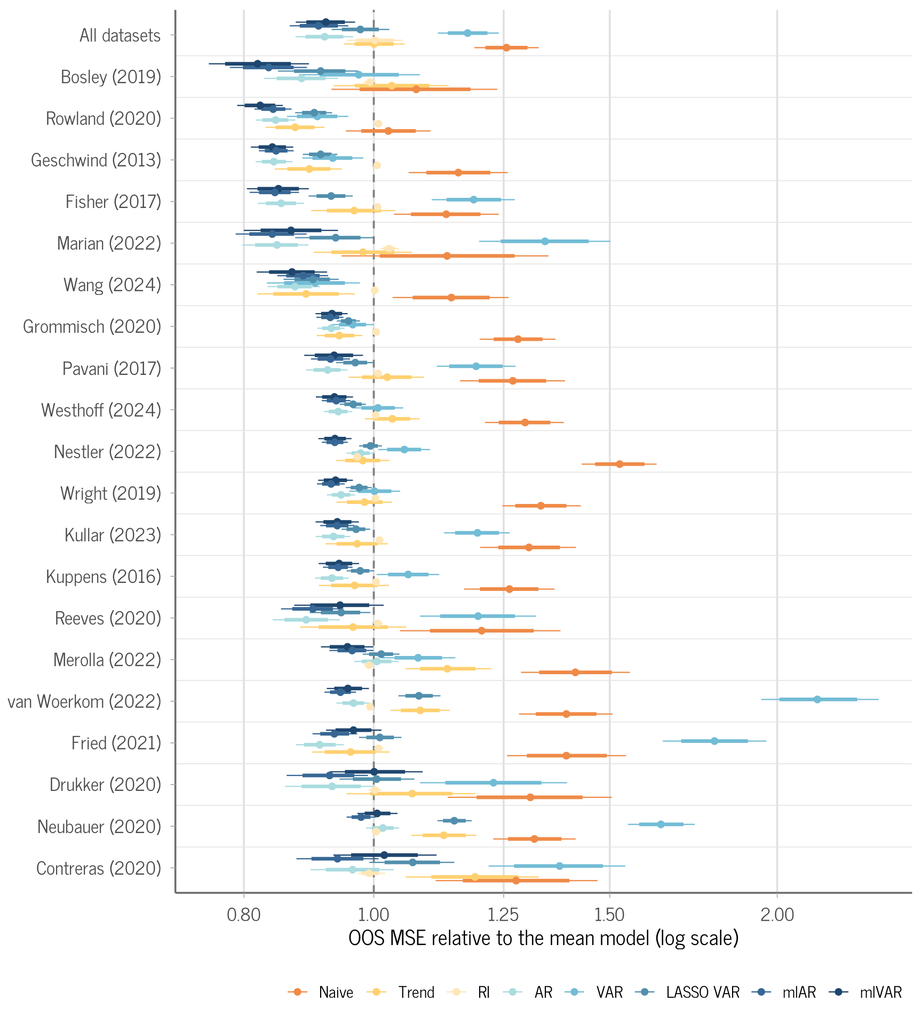

Figure 2: M1: dataset-level OOS MSE relative to the mean model. Points are posterior medians, thick bars are 80% and thin bars 95% CrIs. All datasets is the population-level estimate.

```r
# the linear predictor without the person effect is the dataset-level location of log relMSE
m1_datasets <- expand_grid(model = levels(fit_m1$data$model),
                           dataset_id = unique(fit_m1$data$dataset_id)) |>
  # Keep dataset and dataset:model effects
  add_linpred_draws(fit_m1, re_formula = ~ (1 | dataset_id) + (1 | dataset_id:model)) |>
  ungroup() |>
  left_join(dataset_labels, by = "dataset_id") |>
  mutate(rel_mse = exp(.linpred)) |>
  select(.draw, model, dataset, rel_mse)

m1_population <- coef_draws(fit_m1, "b_model") |>
  mutate(rel_mse = exp(value), dataset = "All datasets") |>
  select(.draw, model, dataset, rel_mse)

# lowest mlVAR error at the top, below the population-level row
forest_order <- m1_datasets |>
  filter(model == "ml_var") |>
  summarise(median = median(rel_mse), .by = dataset) |>
  arrange(desc(median)) |>
  pull(dataset)

m1_forest <- bind_rows(m1_datasets, m1_population) |>
  mutate(dataset = factor(dataset, levels = c(forest_order, "All datasets")),
         model = factor(model, levels = meta_order, labels = meta_labels))

ggplot(m1_forest, aes(x = rel_mse, y = dataset, colour = model)) +
  geom_hline(yintercept = seq(1.5, nlevels(m1_forest$dataset) - 0.5, 1),
             colour = "grey90", linewidth = 0.3) +
  geom_vline(xintercept = 1, colour = "grey50", linetype = "dashed") +
  ggdist::stat_pointinterval(position = position_dodge(width = 0.7), .width = c(0.8, 0.95),
                             point_size = 1.5, interval_size_range = c(0.4, 1.2)) +
  scale_x_log10(breaks = ratio_breaks) +
  scale_colour_manual(values = model_palette) +
  labs(x = "OOS MSE relative to the mean model (log scale)", y = NULL, colour = NULL) +
  theme_bs() +
  theme(legend.position = "bottom",
        panel.grid.major.y = element_blank(),
        panel.grid.major.x = element_line(colour = "#E0E0E0")) +
  guides(colour = guide_legend(nrow = 1, byrow = TRUE))

# save to file for paper
ggsave("fig_m1_datasets.pdf", width = 9, height = 10, dpi = 300, path = here("figures"))
```

```r
re_labels <- c("dataset_id" = "Dataset", "dataset_id:model" = "Dataset × model",
               "unique_id" = "Person")

re_sd <- posterior::as_draws_df(fit_m1, variable = "^sd_", regex = TRUE) |>
  as_tibble() |>
  select(starts_with("sd_")) |>
  pivot_longer(everything(), names_to = "term", values_to = "sd") |>
  mutate(term = sub("^sd_(.*)__Intercept$", "\\1", term))
stopifnot(setequal(unique(re_sd$term), names(re_labels)))

re_sd |>
  summarise(sd_ci = fmt_ci(sd), factor_ci = fmt_ci(exp(sd)), .by = term) |>
  mutate(term = factor(re_labels[term], levels = re_labels)) |>
  arrange(term) |>
  knitr::kable(col.names = c("Random intercept", "SD (log scale)", "Factor exp(SD)"))
```

Table 11: M1: standard deviations of the random intercepts of log relative MSE (posterior median and 95% CrI), and the corresponding factor exp(SD) on the relative MSE scale. Dataset × model: how much a model’s dataset-specific effect varies beyond the dataset’s overall level. Whether the model ranking changes between datasets also depends on the gaps between models (see the dataset-level figure).

| Random intercept | SD (log scale) | Factor exp(SD) |
| --- | --- | --- |
| Dataset | 0.06 [0.04, 0.10] | 1.06 [1.04, 1.10] |
| Dataset × model | 0.09 [0.08, 0.11] | 1.09 [1.08, 1.11] |
| Person | 0.00 [0.00, 0.01] | 1.00 [1.00, 1.01] |

## 4.4 Time series gallery

We now select a few persons with good, average, and poor predictions by mlVAR relative to the mean model, and show one typical item per person. We also show the first OOS origin as a dashed line.

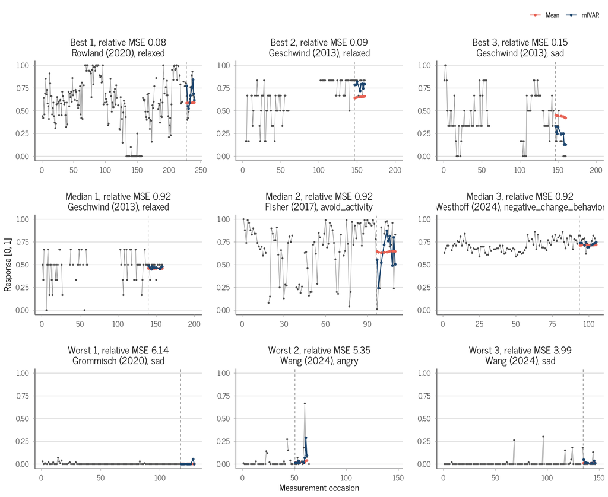

Figure 3: Observed series and OOS predictions for the persons with the lowest, median and highest MSE of mlVAR relative to the mean model. One typical item per person. The dashed line marks the first OOS origin.

```r
# person-level relative MSE of mlVAR, lower is better
person_rel <- combined |>
  filter(set == "oos", model == "ml_var", is.finite(rel_mse)) |>
  select(dataset_id, first_author, year, id, rmse, rel_mse) |>
  arrange(rel_mse, dataset_id, id)

median_rel <- median(person_rel$rel_mse)
selected <- bind_rows(
  slice_min(person_rel, rel_mse, n = 3, with_ties = FALSE) |> mutate(group = "Best"),
  slice_min(person_rel, abs(log(rel_mse / median_rel)), n = 3, with_ties = FALSE) |>
    mutate(group = "Median"),
  slice_max(person_rel, rel_mse, n = 3, with_ties = FALSE) |> mutate(group = "Worst")
) |>
  mutate(rank = row_number(), .by = group)

# item-level MSE ratio of mlVAR vs. the mean model
item_rel <- features$item_error |>
  filter(model %in% c("mean", "ml_var")) |>
  select(dataset_id, id, variable, model, mse) |>
  pivot_wider(names_from = model, values_from = mse, names_prefix = "mse_") |>
  filter(mse_mean > 0, mse_ml_var > 0) |>
  mutate(item_rel = mse_ml_var / mse_mean)

# per person, the item whose ratio is closest to that person's median item ratio (on the log axis)
gallery_items <- selected |>
  select(dataset_id, first_author, year, id, rel_mse, group, rank) |>
  inner_join(item_rel, by = c("dataset_id", "id")) |>
  slice_min(abs(log(item_rel / median(item_rel))), n = 1, with_ties = FALSE,
            by = c(dataset_id, id)) |>
  mutate(group = factor(group, levels = c("Best", "Median", "Worst"))) |>
  arrange(group, rank) |>
  mutate(panel = sprintf("%s %d, relative MSE %.2f\n%s (%s), %s",
                         group, rank, rel_mse, first_author, year, variable),
         panel = factor(panel, levels = panel))

gallery_keys <- select(gallery_items, dataset_id, id, variable, panel)

gallery_series <- features$series |>
  inner_join(gallery_keys, by = c("dataset_id", "id", "variable"))

gallery_preds <- features$oos |>
  filter(model %in% c("mean", "ml_var")) |>
  inner_join(gallery_keys, by = c("dataset_id", "id", "variable")) |>
  mutate(model = factor(model, levels = c("mean", "ml_var"), labels = c("Mean", "mlVAR")))

first_origin <- summarise(gallery_preds, t0 = min(t), .by = panel)

ggplot(gallery_series, aes(x = t, y = y)) +
  geom_vline(data = first_origin, aes(xintercept = t0 - 0.5),
             linetype = "dashed", colour = "grey50", linewidth = 0.3) +
  geom_line(colour = "grey60", linewidth = 0.3) +
  geom_point(colour = "grey30", size = 0.5) +
  geom_line(data = gallery_preds, aes(y = yhat, colour = model), linewidth = 0.6) +
  geom_point(data = gallery_preds, aes(y = yhat, colour = model), size = 1) +
  scale_colour_manual(values = model_palette, name = NULL) +
  ggh4x::facet_wrap2(~ panel, ncol = 3, scales = "free_x", axes = "all") +
  coord_cartesian(ylim = c(0, 1)) +
  labs(x = "Measurement occasion", y = "Response [0, 1]") +
  theme_bs(base_size = 11)
```

## 4.5 Absolute vs. relative performance

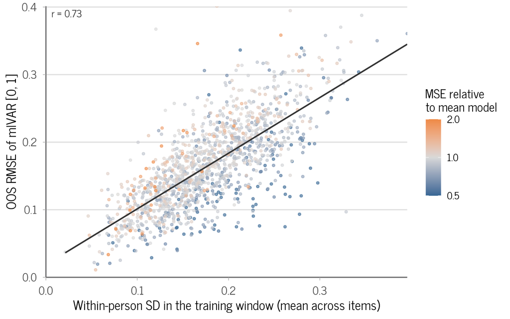

Figure 4: Person-level OOS RMSE of mlVAR by within-person variability in the training window, coloured by MSE relative to the mean model.

```r
abs_rel <- person_rel |>
  left_join(select(features$person, dataset_id, id, sd_train_mean), by = c("dataset_id", "id"))

stopifnot(!anyNA(abs_rel$sd_train_mean))

r_sd_rmse <- cor(abs_rel$sd_train_mean, abs_rel$rmse)

ggplot(abs_rel, aes(x = sd_train_mean, y = rmse, colour = rel_mse)) +
  geom_point(alpha = 0.6, size = 1) +
  geom_smooth(method = "lm", formula = y ~ x, se = FALSE, colour = "grey20",
              linewidth = 0.8) +
  annotate("text", x = -Inf, y = Inf, label = sprintf("r = %.2f", r_sd_rmse),
           hjust = -0.2, vjust = 1.5, size = 4, colour = "grey20") +
  # log colour scale centred on 1 (same error as the mean model)
  scale_colour_gradient2(low = component_palette[["Autoregression"]], mid = "grey85",
                         high = component_palette[["Cross-dynamics"]], midpoint = 1,
                         transform = "log10", limits = c(0.5, 2), oob = scales::oob_squish,
                         breaks = c(0.5, 1, 2), name = "MSE relative\nto mean model") +
  coord_cartesian(xlim = c(0, NA), ylim = c(0, NA), expand = FALSE) +
  labs(x = "Within-person SD in the training window (mean across items)",
       y = "OOS RMSE of mlVAR [0, 1]") +
  theme_bs() +
  theme(legend.position = "right")
```

This strong correlation suggests that the absolute performance of mlVAR is largely determined by the within-person variability of the series.

## 4.6 Item-specific effects

We first look at the raw prediction error per item. For every item, we take the median OOS RMSE across persons, in points of the scale range (items rescaled to [0, 1] and multiplied by 100), for the mean model, AR and VAR. The figure shows the 10 items with the lowest and the 10 with the highest median RMSE of the mean model. As the mean model’s error is essentially the item’s within-person variability, this ranking mainly reflects how much an item varies. The distance between the three points of an item shows how much the dynamic models change the raw error. The two columns on the right describe the item’s dataset: the median number of training observations at the first forecast origin and the median number of training observations per VAR coefficient, across the dataset’s persons. The second column is the training length divided by the number of coefficients per VAR equation (number of items plus intercept), so it is small for datasets with many items and short series.

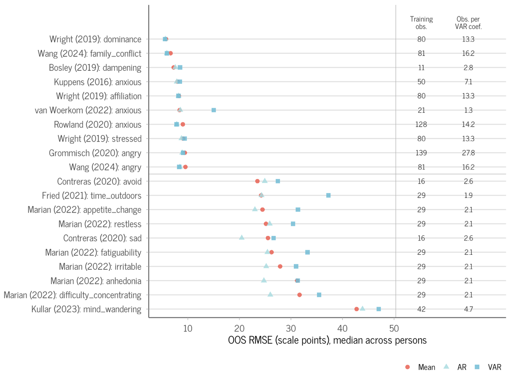

Figure 5: Items with the lowest and highest median OOS RMSE of the mean model, with the RMSE of AR and VAR for comparison.

```r
n_extreme <- 10
rmse_models <- c("mean", "ar", "var")

# medians across the persons of a dataset, the same for all items of that dataset
dataset_design <- features$person |>
  summarise(n_train = median(n_train_first), obs_per_coef = median(obs_per_var_eq_par),
            .by = dataset_id)

# two text columns right of the points, each item in its row, the headers above the top row.
# rows: y plus the table values, and the facet variable if the plot is facetted
table_layers <- function(rows, x_pos, header_y) {
  cells <- bind_rows(
    mutate(rows, x = x_pos[1], label = sprintf("%.0f", n_train)),
    mutate(rows, x = x_pos[2], label = sprintf("%.1f", obs_per_coef))
  )
  header_text <- tibble(x = x_pos, label = c("Training\nobs.", "Obs. per\nVAR coef."),
                        y = header_y)
  facet_cols <- setdiff(names(rows), c("y", "n_train", "obs_per_coef"))
  headers <- if (length(facet_cols) > 0) {
    cross_join(distinct(rows[facet_cols]), header_text)
  } else {
    header_text
  }
  list(
    geom_text(data = cells, aes(x = x, y = y, label = label), inherit.aes = FALSE,
              size = 3.5, colour = "grey20", family = "news"),
    geom_text(data = headers, aes(x = x, y = y, label = label), inherit.aes = FALSE,
              size = 3.5, colour = "grey20", family = "news", vjust = 0, lineheight = 0.9)
  )
}

item_rmse <- features$item_error |>
  filter(model %in% rmse_models) |>
  summarise(rmse = 100 * median(rmse), .by = c(dataset_id, variable, model)) |>
  left_join(dataset_labels, by = "dataset_id") |>
  left_join(dataset_design, by = "dataset_id") |>
  mutate(item = paste0(dataset, ": ", variable))

rmse_rank <- item_rmse |>
  filter(model == "mean") |>
  arrange(rmse)
shown_items <- c(head(rmse_rank$item, n_extreme), tail(rmse_rank$item, n_extreme))

item_rmse_extremes <- item_rmse |>
  filter(item %in% shown_items) |>
  # lowest error at the top
  mutate(item = factor(item, levels = rev(shown_items)),
         model = factor(model, levels = rmse_models,
                        labels = model_labels[match(rmse_models, model_order)]))

# the points use the left part of the panel, the table the right part
rmse_range <- range(item_rmse_extremes$rmse)
rmse_span <- diff(rmse_range)
rmse_table_x <- rmse_range[2] + c(0.2, 0.42) * rmse_span

ggplot(item_rmse_extremes, aes(x = rmse, y = item, colour = model, shape = model)) +
  # separates the lowest from the highest items, and the points from the table
  geom_hline(yintercept = n_extreme + 0.5, colour = "grey70", linewidth = 0.3) +
  geom_vline(xintercept = rmse_range[2] + 0.08 * rmse_span, colour = "grey70", linewidth = 0.3) +
  geom_point(size = 2.5, alpha = 0.85) +
  table_layers(distinct(item_rmse_extremes, y = item, n_train, obs_per_coef), rmse_table_x,
               header_y = 2 * n_extreme + 0.7) +
  scale_colour_manual(values = model_palette) +
  # AR and VAR have similar colours in model_palette
  scale_shape_manual(values = c(Mean = 16, AR = 17, VAR = 15)) +
  scale_x_continuous(breaks = scales::breaks_pretty()(rmse_range)) +
  scale_y_discrete(expand = expansion(add = c(0.6, 2.4))) +
  coord_cartesian(xlim = c(rmse_range[1], rmse_range[2] + 0.52 * rmse_span)) +
  labs(x = "OOS RMSE (scale points), median across persons", y = NULL, colour = NULL,
       shape = NULL) +
  theme_bs() +
  theme(legend.position = "bottom")
```

```r
item_contrasts <- c(ar = "AR vs. mean", var = "VAR vs. mean")
# as zero_tol in relative_mse(): an exact fit leaves floating-point noise instead of 0
zero_tol <- 1e-10

item_mse <- features$item_error |>
  filter(model %in% c("mean", names(item_contrasts))) |>
  select(dataset_id, id, variable, model, mse) |>
  pivot_wider(names_from = model, values_from = mse, names_prefix = "mse_") |>
  pivot_longer(c(mse_ar, mse_var), names_to = "model", names_prefix = "mse_",
               values_to = "mse_model")

# item-level MSE ratio of each model vs. the mean model, per person
item_ratio <- item_mse |>
  filter(mse_mean >= zero_tol, mse_model >= zero_tol) |>
  mutate(ratio = mse_model / mse_mean)

item_rho1 <- features$item |>
  summarise(rho1_median = median(rho1_train, na.rm = TRUE), .by = c(dataset_id, variable))

item_summary <- item_ratio |>
  summarise(ratio = geo_mean(ratio), n_persons = n(), .by = c(dataset_id, variable, model)) |>
  left_join(item_rho1, by = c("dataset_id", "variable")) |>
  left_join(dataset_labels, by = "dataset_id") |>
  mutate(item = paste0(dataset, ": ", variable),
         contrast = factor(item_contrasts[model], levels = item_contrasts))

stopifnot(!anyNA(item_summary$dataset))
```

An item-level ratio is undefined if the mean model or the compared model predicts all test values of an item exactly, for example when the item is constant in the test window. As for the person-level relMSE, an MSE below 10<sup>-10</sup> counts as zero. These person-item combinations are left out of the item ratios.

```r
item_cells <- distinct(item_mse, dataset_id, id, variable, mse_mean)
zero_model <- item_mse |>
  summarise(n = sum(mse_model < zero_tol, na.rm = TRUE), .by = model)
n_zero <- function(m) zero_model$n[zero_model$model == m]
```

Of the 10205 person-item combinations, the test-window MSE was zero in 4 for the mean model, in 11 for AR and in 6 for VAR.

The next figure shows, separately for AR and VAR, the 10 items with the lowest and the 10 items with the highest OOS MSE relative to the mean model. Each point is the geometric mean of the item’s ratio across persons, and its colour is the item’s median lag-1 autocorrelation in the training window. As in the previous figure, the columns on the right give the training length and the training observations per VAR coefficient of the item’s dataset. Together, colour and columns show whether an item’s ranking follows from its autocorrelation or from the amount of data per parameter in its dataset.

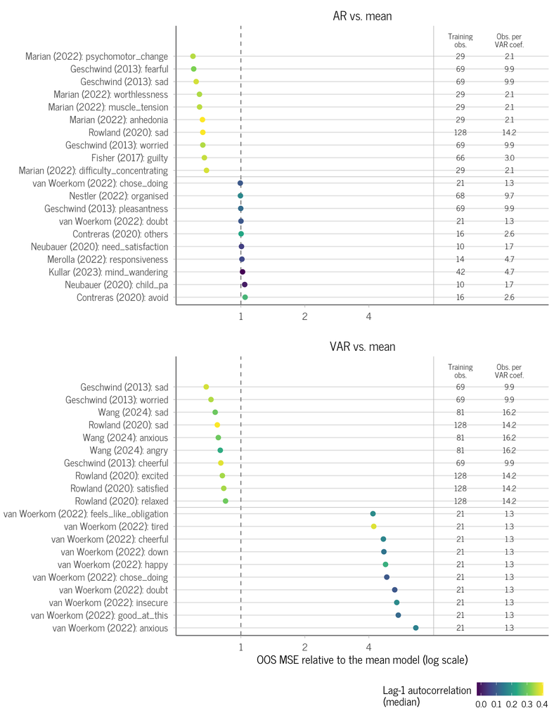

Figure 6: The 10 items with the lowest and highest OOS MSE relative to the mean model, per contrast, with the training length and the training observations per VAR coefficient of their dataset.

```r
n_extreme <- 10

item_extremes <- bind_rows(
  slice_min(item_summary, ratio, n = n_extreme, with_ties = FALSE, by = contrast),
  slice_max(item_summary, ratio, n = n_extreme, with_ties = FALSE, by = contrast)
) |>
  left_join(dataset_design, by = "dataset_id") |>
  # an item ranks differently per contrast, so each panel needs its own y levels.
  # lowest error at the top
  mutate(item_key = reorder(paste(item, contrast, sep = "__"), desc(ratio)))

# on the log axis, the table positions are multiples of the largest ratio
ratio_range <- range(item_extremes$ratio)
log_span <- log10(ratio_range[2] / ratio_range[1])
ratio_table_x <- ratio_range[2] * 10^(c(0.2, 0.42) * log_span)
ratio_breaks_shown <- 2^(-8:8)
ratio_breaks_shown <- ratio_breaks_shown[ratio_breaks_shown >= ratio_range[1] / 1.05 &
                                           ratio_breaks_shown <= ratio_range[2] * 1.05]

ggplot(item_extremes, aes(x = ratio, y = item_key, colour = rho1_median)) +
  geom_vline(xintercept = 1, colour = "grey50", linetype = "dashed") +
  # separates the lowest from the highest items, and the points from the table
  geom_hline(yintercept = n_extreme + 0.5, colour = "grey70", linewidth = 0.3) +
  geom_vline(xintercept = ratio_range[2] * 10^(0.08 * log_span), colour = "grey70",
             linewidth = 0.3) +
  geom_point(size = 2.5) +
  table_layers(distinct(item_extremes, y = item_key, contrast, n_train, obs_per_coef),
               ratio_table_x, header_y = 2 * n_extreme + 0.7) +
  scale_y_discrete(labels = \(x) sub("__.*$", "", x), expand = expansion(add = c(0.6, 2.4))) +
  scale_x_log10(breaks = ratio_breaks_shown) +
  coord_cartesian(xlim = c(ratio_range[1], ratio_range[2] * 10^(0.52 * log_span))) +
  scale_colour_viridis_c(name = "Lag-1 autocorrelation\n(median)") +
  ggh4x::facet_wrap2(~ contrast, ncol = 1, scales = "free_y", axes = "all") +
  labs(x = "OOS MSE relative to the mean model (log scale)", y = NULL) +
  theme_bs() +
  theme(legend.position = "bottom")
```

# 5 Decomposition of predictive gains

## 5.1 Model-based steps (M1)

Within each dataset, ratios are geometric means across persons with defined relMSE for all five models. “All datasets” gives each dataset equal weight.

```r
step_types <- c("Reference", "Autoregression", "Cross-lags", "Pooling", "Regularisation",
                "Trend", "Total")
steps <- tribble(
  ~type, ~from, ~to,
  "Reference", "mean", "naive",
  "Autoregression", "mean", "ar",
  "Autoregression", "ri", "ml_ar",
  "Cross-lags", "ar", "var",
  "Cross-lags", "ml_ar", "ml_var",
  "Pooling", "mean", "ri",
  "Pooling", "ar", "ml_ar",
  "Pooling", "var", "ml_var",
  "Regularisation", "var", "lasso_var",
  "Trend", "mean", "trend",
  "Total", "mean", "ml_var"
) |>
  mutate(type = factor(type, levels = step_types),
         step = paste(model_labels[match(from, model_order)], "→",
                      model_labels[match(to, model_order)]))

# log relative MSE per draw, one column per model; the mean model is the reference, so 0
log_rel_mse <- coef_draws(fit_m1, "b_model") |>
  pivot_wider(names_from = model, values_from = value) |>
  mutate(mean = 0)

oos_wide <- combined |>
  filter(set == "oos", is.finite(rel_mse)) |>
  mutate(model = as.character(model)) |>
  select(dataset_id, id, model, rel_mse) |>
  pivot_wider(names_from = model, values_from = rel_mse)
stopifnot(all(c(steps$from, steps$to) %in% names(oos_wide)))

step_summary <- lapply(seq_len(nrow(steps)), function(i) {
  from <- steps$from[i]
  to <- steps$to[i]
  ratio <- exp(log_rel_mse[[to]] - log_rel_mse[[from]])
  paired <- is.finite(oos_wide[[from]]) & is.finite(oos_wide[[to]])
  before <- oos_wide[[from]][paired]
  after <- oos_wide[[to]][paired]
  tibble(ratio_ci = fmt_ci(ratio), p_lower = mean(ratio < 1),
         improved = mean(after < before), ties = sum(after == before), n = sum(paired))
}) |>
  bind_rows()
steps <- bind_cols(steps, step_summary)

step_table <- steps |>
  mutate(improved = sprintf("%.0f%%", 100 * improved)) |>
  select(type, step, ratio_ci, p_lower, improved, n, ties)
# ties: equal relative MSE, counted as not improved. shown only if any occur
if (all(steps$ties == 0)) step_table <- select(step_table, -ties)

step_col_names <- c(type = "Type", step = "Step", ratio_ci = "Error ratio [95% CrI]",
                    p_lower = "P(< 1)", improved = "Improved", n = "n", ties = "Ties")
knitr::kable(step_table, digits = 2, col.names = step_col_names[names(step_table)])
```

Table 12: Change in OOS MSE for each step of the complexity ladder. Error ratio: population-level relative MSE after vs. before the step in M1 (posterior median and 95% CrI), with the posterior probability that the step lowers the error. Improved: share of persons with lower OOS relative MSE after the step, among the n persons with a defined relative MSE for both models. The error ratio uses all persons in M1, the share only the paired persons.

| Type | Step | Error ratio [95% CrI] | P(< 1) | Improved | n |
| --- | --- | --- | --- | --- | --- |
| Reference | Mean → Naive | 1.26 [1.19, 1.33] | 0.00 | 29% | 1127 |
| Autoregression | Mean → AR | 0.92 [0.87, 0.97] | 1.00 | 74% | 1408 |
| Autoregression | RI → mlAR | 0.91 [0.86, 0.96] | 1.00 | 82% | 1416 |
| Cross-lags | AR → VAR | 1.28 [1.20, 1.36] | 0.00 | 23% | 1405 |
| Cross-lags | mlAR → mlVAR | 1.01 [0.96, 1.07] | 0.34 | 51% | 1416 |
| Pooling | Mean → RI | 1.00 [0.96, 1.05] | 0.47 | 39% | 1416 |
| Pooling | AR → mlAR | 0.99 [0.93, 1.05] | 0.63 | 53% | 1408 |
| Pooling | VAR → mlVAR | 0.78 [0.74, 0.83] | 1.00 | 81% | 1411 |
| Regularisation | VAR → LASSO VAR | 0.83 [0.78, 0.88] | 1.00 | 72% | 1411 |
| Trend | Mean → Trend | 1.00 [0.95, 1.05] | 0.49 | 54% | 1416 |
| Total | Mean → mlVAR | 0.92 [0.87, 0.97] | 1.00 | 70% | 1416 |

```r
# the paper version: grouped by step type, as in the model overview table. needs booktabs
step_rows <- unlist(lapply(levels(droplevels(steps$type)), function(type) {
  group <- steps[steps$type == type, ]
  step_tex <- paste(model_labels[match(group$from, model_order)], "$\\rightarrow$",
                    model_labels[match(group$to, model_order)])
  c(paste0("\\multicolumn{5}{@{}l}{\\textit{", type, "}} \\\\"),
    sprintf("\\quad %s & %s & %.2f & %.0f\\%% & %d \\\\", step_tex, group$ratio_ci,
            group$p_lower, 100 * group$improved, group$n))
}))

decomposition_tex <- c(
  "\\begin{table}[ht]",
  "\\centering",
  "\\caption{Decomposition of Predictive Gains}",
  "\\label{tab:decomposition}",
  "\\small",
  "\\begin{tabular}{@{}lrrrr@{}}",
  "\\toprule",
  "Step & Error ratio [95\\% CrI] & $P(< 1)$ & Improved & $n$ \\\\",
  "\\midrule",
  step_rows,
  "\\bottomrule",
  "\\end{tabular}",
  "",
  "\\vspace{0.4em}",
  paste("\\noindent \\raggedright \\textit{Note.} Error ratio: out-of-sample relMSE after vs.",
        "before the step, estimated with meta-model M1 (posterior median and 95\\% credible",
        "interval). Values below 1 indicate lower error after the step. $P(< 1)$: posterior",
        "probability that the step lowers the error. Improved: share of the $n$ persons with a",
        "defined relMSE for both models whose relMSE is lower after the step. Any reduction",
        "counts as an improvement, however small, so about 50\\% are expected if two models",
        "predict equally well. Persons with identical relMSE for both models count as not",
        "improved."),
  "\\end{table}"
)
writeLines(decomposition_tex, here("output", "paper", "tbl_decomposition.tex"))
```

## 5.2 Model dominance

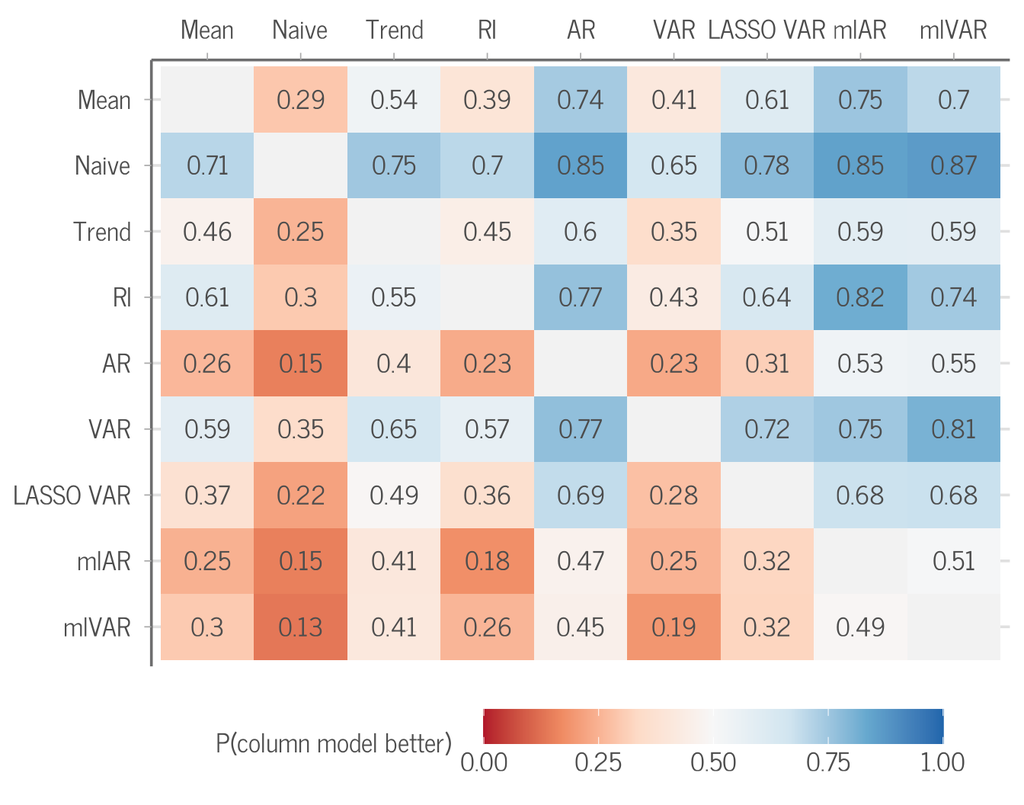

Figure 7: Pairwise model dominance: Proportion of persons where the column model has lower OOS relative MSE than the row model. The Mean row is the share of persons for whom a model beats the mean model. Without a true difference, about 0.5 is expected from noise alone.

```r
model_pairs <- expand.grid(model_a = model_labels, model_b = model_labels,
                           stringsAsFactors = FALSE)

# comparing rel_mse within a person compares geometric-mean MSE over items
dat_wide <- combined |>
  filter(set == "oos", is.finite(rel_mse)) |>
  mutate(model = factor(model, levels = model_order, labels = model_labels)) |>
  select(dataset_id, id, model, rel_mse) |>
  pivot_wider(names_from = model, values_from = rel_mse)

dominance <- model_pairs |>
  rowwise() |>
  mutate(
    prop = if_else(model_a == model_b, NA_real_,
                   mean(dat_wide[[model_a]] < dat_wide[[model_b]], na.rm = TRUE))
  ) |>
  ungroup() |>
  mutate(
    model_a = factor(model_a, levels = model_labels),
    model_b = factor(model_b, levels = rev(model_labels))
  )

dominance_text_size <- 14 * 0.9

ggplot(dominance, aes(x = model_a, y = model_b, fill = prop)) +
  geom_tile() +
  geom_text(aes(label = round(prop, 2)), size = dominance_text_size / ggplot2::.pt,
            colour = "grey30", family = "news") +
  scale_fill_distiller(palette = "RdBu", limits = c(0, 1), direction = 1,
                       na.value = "grey95",
                       name = "P(column model better)") +
  labs(x = NULL, y = NULL) +
  scale_x_discrete(position = "top") +
  theme_bs() +
  guides(fill = guide_colorbar(
    barwidth = grid::unit(8, "cm"),
    title.position = "left"
  )) +
  theme(
    legend.position = "bottom",
    legend.justification = "center",
    legend.title = element_text(
      family = "news", size = dominance_text_size, colour = "grey30",
      margin = margin(r = 16)
    ),
    legend.text = element_text(
      family = "news", size = dominance_text_size, colour = "grey30",
      margin = margin(t = 4)
    )
  )
```

# 6 Moderators

## 6.1 Moderator descriptives

```r
features$person |>
  summarise(n_train = sprintf("%g [%g, %g]", median(n_train_first), min(n_train_first),
                              max(n_train_first)),
            rho1 = sprintf("%.2f (%.2f)", mean(rho1_train_mean, na.rm = TRUE),
                           sd(rho1_train_mean, na.rm = TRUE)),
            .by = dataset_id) |>
  left_join(dataset_labels, by = "dataset_id") |>
  arrange(first_author, year) |>
  select(dataset, n_train, rho1) |>
  knitr::kable(col.names = c("Dataset", "Training length", "Autocorrelation"))
```

Table 14: Moderators of M2 and M3 per dataset: training length in the first fold (median [range] across persons) and mean lag-1 autocorrelation of the items in the training window (mean (SD) across persons).

| Dataset | Training length | Autocorrelation |
| --- | --- | --- |
| Bosley (2019) | 11 [10, 22] | 0.26 (0.25) |
| Contreras (2020) | 15.5 [10, 25] | 0.27 (0.14) |
| Drukker (2020) | 33 [16, 90] | 0.26 (0.13) |
| Fisher (2017) | 66.5 [46, 100] | 0.35 (0.11) |
| Fried (2021) | 29 [13, 32] | 0.21 (0.10) |
| Geschwind (2013) | 69 [10, 95] | 0.30 (0.14) |
| Grommisch (2020) | 139 [41, 171] | 0.28 (0.14) |
| Kullar (2023) | 42 [12, 46] | 0.18 (0.15) |
| Kuppens (2016) | 50 [29, 62] | 0.21 (0.15) |
| Marian (2022) | 29 [19, 32] | 0.31 (0.17) |
| Merolla (2022) | 14 [10, 36] | 0.16 (0.23) |
| Nestler (2022) | 68 [17, 71] | 0.15 (0.08) |
| Neubauer (2020) | 10 [10, 10] | 0.07 (0.16) |
| Pavani (2017) | 29 [14, 45] | 0.23 (0.16) |
| Reeves (2020) | 67 [50, 80] | 0.26 (0.14) |
| Rowland (2020) | 128 [34, 176] | 0.34 (0.14) |
| Wang (2024) | 81 [21, 95] | 0.29 (0.15) |
| Westhoff (2024) | 68 [44, 74] | 0.23 (0.13) |
| Wright (2019) | 80 [44, 90] | 0.22 (0.10) |
| van Woerkom (2022) | 21 [10, 34] | 0.18 (0.14) |

```r
moderators <- features$person |>
  select(dataset_id, n_train_first, rho1_train_mean)

moderator_datasets <- moderators |>
  summarise(n_train = median(n_train_first), rho1 = mean(rho1_train_mean, na.rm = TRUE),
            .by = dataset_id)

fmt_iqr <- function(x, digits) {
  sprintf(paste0("%.", digits, "f, %.", digits, "f"), quantile(x, 0.25, na.rm = TRUE),
          quantile(x, 0.75, na.rm = TRUE))
}
fmt_span <- function(x, digits) {
  sprintf(paste0("%.", digits, "f to %.", digits, "f"), min(x, na.rm = TRUE), max(x, na.rm = TRUE))
}
```

Across all 1420 persons, the training window at the first forecast origin contained a median of 63 observations (IQR [31, 83], range 10 to 176), and the dataset medians ranged from 10 to 139. The mean lag-1 autocorrelation of the items in the training window was 0.24 on average (SD 0.16, IQR [0.14, 0.33]), with dataset means from 0.07 to 0.35. Persons with an undefined autocorrelation (n = 0) are not part of M3.

## 6.2 M2 (M1 + training length)

Each moderator is split into a between part, the dataset mean, and a within part, the person’s deviation from that mean. We added that due to large dataset-specific differences. The within slope compares persons in the same dataset, the between slope compares datasets. Because the moderators enter log relative MSE linearly, each slope is a constant ratio: the factor by which a model’s relative MSE changes per doubling of the training length, regardless of the other predictors. Ratios below 1 mean that the model gains on the mean model as the training window grows.

```r
# exp(step * slope) is the ratio of relative MSE per step of the moderator
moderator_ratios <- function(fit, steps) {
  lapply(names(steps), \(moderator) {
    step <- steps[[moderator]]
    coef_draws(fit, "b_model", suffix = paste0(":", moderator)) |>
      mutate(term = moderator, ratio = exp(step * value))
  }) |>
    bind_rows() |>
    summarise(ratio_ci = fmt_ci(ratio), .by = c(model, term)) |>
    pivot_wider(names_from = term, values_from = ratio_ci) |>
    mutate(model = factor(model, levels = meta_order, labels = meta_labels)) |>
    select(model, all_of(names(steps))) |>
    arrange(model)
}

moderator_ratios(fit_m2, c(log_n_within = log(2), log_n_between = log(2))) |>
  knitr::kable(col.names = c("Model", "Training length, within", "Training length, between"))
```

Table 15: M2: factor by which the OOS MSE relative to the mean model changes per doubling of the training length, within and between datasets. Posterior medians and 95% CrIs.

| Model | Training length, within | Training length, between |
| --- | --- | --- |
| Naive | 0.95 [0.89, 1.01] | 0.98 [0.94, 1.03] |
| Trend | 0.91 [0.88, 0.95] | 0.94 [0.90, 0.98] |
| RI | 1.00 [1.00, 1.00] | 1.00 [0.96, 1.04] |
| AR | 0.94 [0.92, 0.96] | 0.98 [0.94, 1.02] |
| VAR | 0.83 [0.80, 0.87] | 0.86 [0.83, 0.90] |
| LASSO VAR | 0.93 [0.91, 0.95] | 0.96 [0.92, 1.00] |
| mlAR | 0.96 [0.94, 0.98] | 0.99 [0.95, 1.03] |
| mlVAR | 0.96 [0.93, 0.98] | 0.98 [0.94, 1.02] |

## 6.3 M3 (M2 + autocorrelation)

M3 adds the mean lag-1 autocorrelation of the items in the training window, also split into a within- and between-dataset component. Its ratios are per 0.1 higher autocorrelation. The training length ratios are now adjusted for autocorrelation.

```r
moderator_ratios(fit_m3, c(log_n_within = log(2), log_n_between = log(2),
                           rho1_within = 0.1, rho1_between = 0.1)) |>
  knitr::kable(col.names = c("Model", "Training length, within", "Training length, between",
                             "Autocorrelation, within", "Autocorrelation, between"))
```

Table 16: M3: factor by which the OOS MSE relative to the mean model changes per doubling of the training length and per 0.1 higher mean lag-1 autocorrelation, within and between datasets. Posterior medians and 95% CrIs.

| Model | Training length, within | Training length, between | Autocorrelation, within | Autocorrelation, between |
| --- | --- | --- | --- | --- |
| Naive | 1.00 [0.94, 1.06] | 1.04 [0.98, 1.09] | 0.93 [0.92, 0.95] | 0.87 [0.80, 0.94] |
| Trend | 0.91 [0.88, 0.95] | 0.94 [0.89, 0.98] | 1.00 [0.99, 1.01] | 1.00 [0.93, 1.07] |
| RI | 1.00 [1.00, 1.00] | 1.00 [0.95, 1.04] | 1.00 [1.00, 1.00] | 1.02 [0.96, 1.08] |
| AR | 0.96 [0.94, 0.98] | 1.00 [0.96, 1.04] | 0.95 [0.95, 0.96] | 0.93 [0.88, 1.00] |
| VAR | 0.85 [0.82, 0.89] | 0.86 [0.82, 0.90] | 0.94 [0.93, 0.95] | 0.98 [0.91, 1.05] |
| LASSO VAR | 0.94 [0.92, 0.96] | 0.97 [0.93, 1.02] | 0.96 [0.96, 0.97] | 0.95 [0.89, 1.02] |
| mlAR | 0.99 [0.97, 1.01] | 1.00 [0.96, 1.05] | 0.96 [0.96, 0.97] | 0.95 [0.88, 1.01] |
| mlVAR | 0.99 [0.96, 1.02] | 0.99 [0.94, 1.03] | 0.96 [0.95, 0.97] | 0.96 [0.89, 1.02] |

## 6.4 Moderation of the steps between models

The slopes above describe each model’s error relative to the mean model. The figures below compare models with each other, for example AR with VAR. To give these comparisons a model-based counterpart, we take the difference between the slopes of two models within each posterior draw. Exponentiated, it is the factor by which the error ratio of the model after the arrow to the model before it changes per doubling of the training length (from M2) or per 0.1 higher lag-1 autocorrelation (from M3). A factor below 1 means that the model after the arrow gains relative to the model before it as the moderator increases. Within-dataset factors compare persons in the same dataset, between-dataset factors compare datasets. Within a dataset, the number of items is constant, so the within-dataset factor for training length also describes the trend in the figure below, whose x-axis is the number of training observations per VAR coefficient. The training length factors come from M2, without adjustment for autocorrelation.

```r
moderator_steps <- tribble(
  ~type, ~from, ~to,
  "Cross-lags", "ar", "var",
  "Cross-lags", "ml_ar", "ml_var",
  "Cross-lags and regularisation", "ar", "lasso_var",
  "Regularisation", "var", "lasso_var",
  "Pooling", "ar", "ml_ar",
  "Pooling", "var", "ml_var"
) |>
  mutate(step = paste(model_labels[match(from, model_order)], "→",
                      model_labels[match(to, model_order)]))

# exp(step size * (slope of the model after the arrow - slope of the model before it)) per draw
step_slopes <- function(fit, moderator, step_size) {
  slopes <- coef_draws(fit, "b_model", suffix = paste0(":", moderator)) |>
    pivot_wider(names_from = model, values_from = value)
  vapply(seq_len(nrow(moderator_steps)), function(i) {
    fmt_ci(exp(step_size * (slopes[[moderator_steps$to[i]]] - slopes[[moderator_steps$from[i]]])))
  }, character(1))
}

moderator_steps |>
  mutate(n_within = step_slopes(fit_m2, "log_n_within", log(2)),
         n_between = step_slopes(fit_m2, "log_n_between", log(2)),
         rho_within = step_slopes(fit_m3, "rho1_within", 0.1),
         rho_between = step_slopes(fit_m3, "rho1_between", 0.1)) |>
  select(type, step, n_within, n_between, rho_within, rho_between) |>
  knitr::kable(col.names = c("Type", "Step", "Training length, within",
                             "Training length, between", "Autocorrelation, within",
                             "Autocorrelation, between"))
```

Table 17: Change in the OOS error ratio between two models per doubling of the training length (M2) and per 0.1 higher lag-1 autocorrelation (M3). Posterior medians and 95% CrIs.

| Type | Step | Training length, within | Training length, between | Autocorrelation, within | Autocorrelation, between |
| --- | --- | --- | --- | --- | --- |
| Cross-lags | AR → VAR | 0.88 [0.85, 0.93] | 0.88 [0.84, 0.93] | 0.99 [0.97, 1.00] | 1.04 [0.96, 1.14] |
| Cross-lags | mlAR → mlVAR | 1.00 [0.96, 1.03] | 0.99 [0.94, 1.04] | 1.00 [0.99, 1.01] | 1.01 [0.93, 1.10] |
| Cross-lags and regularisation | AR → LASSO VAR | 0.99 [0.96, 1.02] | 0.99 [0.94, 1.03] | 1.01 [1.00, 1.02] | 1.02 [0.94, 1.11] |
| Regularisation | VAR → LASSO VAR | 1.12 [1.07, 1.17] | 1.12 [1.06, 1.18] | 1.03 [1.01, 1.04] | 0.98 [0.90, 1.06] |
| Pooling | AR → mlAR | 1.02 [0.99, 1.05] | 1.01 [0.97, 1.06] | 1.01 [1.00, 1.02] | 1.01 [0.93, 1.10] |
| Pooling | VAR → mlVAR | 1.15 [1.10, 1.21] | 1.14 [1.08, 1.19] | 1.02 [1.01, 1.03] | 0.98 [0.90, 1.07] |

## 6.5 Value of cross-dynamics and regularisation by data per parameter

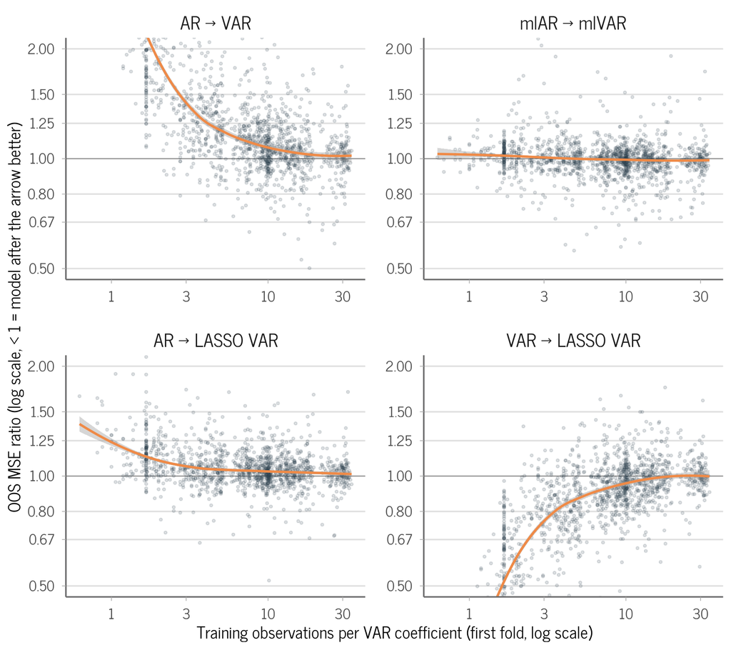

Figure 8: Change in OOS MSE from adding cross-lagged effects and from regularising them, by the number of training observations per VAR coefficient. The y-axis shows the MSE ratio of the model after vs. before the arrow. AR → LASSO VAR combines adding cross-lags with shrinking all lags, and VAR → LASSO VAR shows the value of regularisation.

```r
# y-range symmetric around 1 on the log axis
y_lim_cross <- c(0.5, 2)
cross_levels <- c("AR → VAR", "mlAR → mlVAR", "AR → LASSO VAR", "VAR → LASSO VAR")

cross_dyn <- combined |>
  filter(set == "oos", model %in% c("ar", "var", "lasso_var", "ml_ar", "ml_var"),
         is.finite(rel_mse)) |>
  select(dataset_id, id, model, rel_mse) |>
  pivot_wider(names_from = model, values_from = rel_mse) |>
  mutate(`AR → VAR` = var / ar, `mlAR → mlVAR` = ml_var / ml_ar,
         `AR → LASSO VAR` = lasso_var / ar, `VAR → LASSO VAR` = lasso_var / var) |>
  select(dataset_id, id, all_of(cross_levels)) |>
  pivot_longer(-c(dataset_id, id), names_to = "comparison", values_to = "ratio") |>
  filter(is.finite(ratio)) |>
  mutate(comparison = factor(comparison, levels = cross_levels)) |>
  left_join(select(features$person, dataset_id, id, obs_per_var_eq_par),
            by = c("dataset_id", "id"))

stopifnot(!anyNA(cross_dyn$obs_per_var_eq_par))

beyond_cross <- cross_dyn |>
  summarise(n_below = sum(ratio < y_lim_cross[1]), n_above = sum(ratio > y_lim_cross[2]),
            .by = comparison) |>
  mutate(label = sprintf("%d above, %d below range", n_above, n_below))

ggplot(cross_dyn, aes(x = obs_per_var_eq_par, y = ratio)) +
  geom_hline(yintercept = 1, colour = "grey50", linewidth = 0.3) +
  geom_point(alpha = 0.15, size = 0.8, colour = "#2C3E50") +
  geom_smooth(method = "loess", formula = y ~ x, se = TRUE,
              method.args = list(family = "symmetric"),
              colour = component_palette[["Cross-dynamics"]], linewidth = 1) +
  # draw one line per dataset to show the within-dataset trend
  # geom_smooth(aes(group = dataset_id), method = "lm", se = FALSE,
  #             colour = scales::alpha("grey50", 0.6), linewidth = 0.5) +
  geom_text(data = beyond_cross, aes(x = -Inf, y = Inf, label = label),
            inherit.aes = FALSE, hjust = -0.05, vjust = 1.5, size = 3, colour = "grey30") +
  scale_x_log10() +
  scale_y_log10(breaks = ratio_breaks) +
  ggh4x::facet_wrap2(~ comparison, nrow = 2, axes = "all") +
  coord_cartesian(ylim = y_lim_cross) +
  labs(x = "Training observations per VAR coefficient (first fold, log scale)",
       y = "OOS MSE ratio (log scale, < 1 = model after the arrow better)") +
  theme_bs()

# save figure for paper
ggsave("fig_cross_dynamics.pdf", width = 9, height = 8, dpi = 300,
       path = here("figures"))
```

## 6.6 Value of pooling by series length

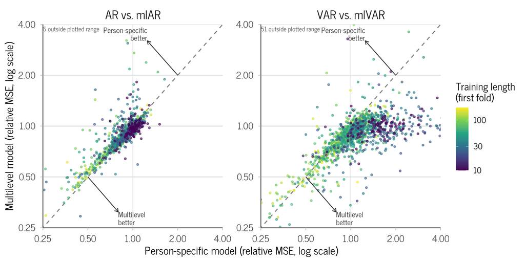

Figure 9: Person-level OOS MSE relative to the mean model: person-specific vs. multilevel model, coloured by training series length. Points below the diagonal: pooling lowered the error.

```r
xy_lim <- c(0.25, 4)

shrinkage <- combined |>
  filter(set == "oos", model %in% c("ar", "ml_ar", "var", "ml_var"), is.finite(rel_mse)) |>
  select(dataset_id, id, model, rel_mse) |>
  pivot_wider(names_from = model, values_from = rel_mse) |>
  pivot_longer(c(ml_ar, ml_var), names_to = "ml_model", values_to = "multilevel") |>
  mutate(person_specific = if_else(ml_model == "ml_ar", ar, var),
         comparison = factor(ml_model, levels = c("ml_ar", "ml_var"),
                             labels = c("AR vs. mlAR", "VAR vs. mlVAR"))) |>
  filter(is.finite(person_specific), is.finite(multilevel)) |>
  left_join(select(features$person, dataset_id, id, n_train_first), by = c("dataset_id", "id")) |>
  # short series last, so they are drawn on top
  arrange(desc(n_train_first))

stopifnot(!anyNA(shrinkage$n_train_first))

beyond_shrinkage <- shrinkage |>
  summarise(n_outside = sum(person_specific < xy_lim[1] | person_specific > xy_lim[2] |
                             multilevel < xy_lim[1] | multilevel > xy_lim[2]),
            .by = comparison) |>
  mutate(label = sprintf("%d outside plotted range", n_outside))

# arrows from the diagonal into the region where each model has the lower error
better_arrows <- tibble(
  x = c(0.5, 2), y = c(0.5, 2),
  xend = c(0.8, 1.25), yend = c(0.31, 3.2),
  label = c("Multilevel\nbetter", "Person-specific\nbetter"),
  hjust = c(0, 1), vjust = c(1, 0)
)

ggplot(shrinkage, aes(x = person_specific, y = multilevel, colour = n_train_first)) +
  geom_hline(yintercept = 1, colour = "grey85", linewidth = 0.3) +
  geom_vline(xintercept = 1, colour = "grey85", linewidth = 0.3) +
  geom_abline(slope = 1, intercept = 0, colour = "grey50", linetype = "dashed") +
  geom_point(alpha = 0.6, size = 0.9) +
  geom_segment(data = better_arrows, aes(x = x, y = y, xend = xend, yend = yend),
               arrow = arrow(length = unit(0.2, "cm")), colour = "grey20", linewidth = 0.5,
               inherit.aes = FALSE) +
  geom_text(data = better_arrows,
            aes(x = xend, y = yend, label = label, hjust = hjust, vjust = vjust),
            size = 3.5, colour = "grey20", lineheight = 0.9, inherit.aes = FALSE) +
  geom_text(data = beyond_shrinkage, aes(x = xy_lim[1], y = xy_lim[2], label = label),
            inherit.aes = FALSE, hjust = 0, vjust = 1.5, size = 3, colour = "grey30") +
  scale_x_log10(breaks = c(0.25, 0.5, 1, 2, 4)) +
  scale_y_log10(breaks = c(0.25, 0.5, 1, 2, 4)) +
  scale_colour_viridis_c(transform = "log10", name = "Training length\n(first fold)") +
  ggh4x::facet_wrap2(~ comparison, axes = "all") +
  coord_cartesian(xlim = xy_lim, ylim = xy_lim, expand = FALSE) +
  labs(x = "Person-specific model (relative MSE, log scale)",
       y = "Multilevel model (relative MSE, log scale)") +
  theme_bs() +
  theme(legend.position = "right")
```

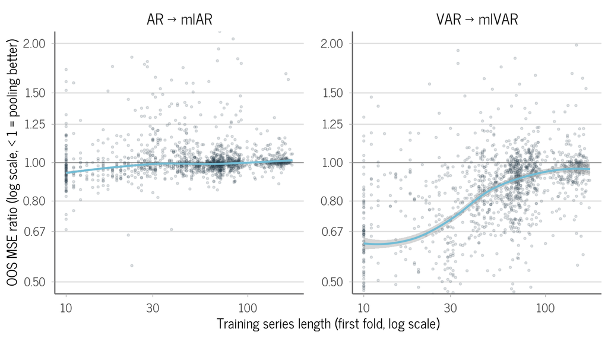

Figure 10: Change in OOS MSE from pooling, by the person’s training series length. The y-axis shows the MSE ratio of the multilevel vs. the person-specific model.

```r
# y-range symmetric around 1 on the log axis
y_lim <- c(0.5, 2)

pooling <- combined |>
  filter(set == "oos", model %in% c("ar", "ml_ar", "var", "ml_var"), is.finite(rel_mse)) |>
  select(dataset_id, id, model, rel_mse) |>
  pivot_wider(names_from = model, values_from = rel_mse) |>
  mutate(`AR → mlAR` = ml_ar / ar, `VAR → mlVAR` = ml_var / var) |>
  select(dataset_id, id, `AR → mlAR`, `VAR → mlVAR`) |>
  pivot_longer(-c(dataset_id, id), names_to = "comparison", values_to = "ratio") |>
  filter(is.finite(ratio)) |>
  left_join(select(features$person, dataset_id, id, n_train_first),
            by = c("dataset_id", "id"))

stopifnot(!anyNA(pooling$n_train_first))

beyond <- pooling |>
  summarise(n_below = sum(ratio < y_lim[1]), n_above = sum(ratio > y_lim[2]),
            .by = comparison) |>
  mutate(label = sprintf("%d above, %d below range", n_above, n_below))

# robust loess downweights persons whose person-specific model breaks down.
# it is fitted on the log axis, so improvements and deteriorations count alike
ggplot(pooling, aes(x = n_train_first, y = ratio)) +
  geom_hline(yintercept = 1, colour = "grey50", linewidth = 0.3) +
  geom_point(alpha = 0.15, size = 0.8, colour = "#2C3E50") +
  geom_smooth(method = "loess", formula = y ~ x, se = TRUE,
              method.args = list(family = "symmetric"),
              colour = component_palette[["Pooling"]], linewidth = 1) +
  # draw one line per dataset to show the within-dataset trend
  # geom_smooth(aes(group = dataset_id), method = "lm", se = FALSE,
  #             colour = scales::alpha("grey50", 0.6), linewidth = 0.5) +
  geom_text(data = beyond, aes(x = -Inf, y = Inf, label = label),
            inherit.aes = FALSE, hjust = -0.05, vjust = 1.5, size = 3, colour = "grey30") +
  scale_x_log10() +
  scale_y_log10(breaks = ratio_breaks) +
  ggh4x::facet_wrap2(~ comparison, axes = "all") +
  coord_cartesian(ylim = y_lim) +
  labs(x = "Training series length (first fold, log scale)",
       y = "OOS MSE ratio (log scale, < 1 = pooling better)") +
  theme_bs()
```

# 7 Sensitivity analyses

S1 replaces the Student-t likelihood of M1 with a lognormal likelihood on relative MSE. S4 models the log geometric mean of the raw MSE across items instead of relative MSE and includes the mean model, so its estimates are expressed relative to the mean model’s estimate.

```r
# exp(b) is the population-level relative MSE. a model that includes the mean model (S4) is
# expressed relative to it within each draw
relative_to_mean <- function(fit) {
  draws <- coef_draws(fit, "b_model")
  if ("mean" %in% draws$model) {
    draws <- draws |>
      mutate(value = value - value[model == "mean"], .by = .draw) |>
      filter(model != "mean")
  }
  summarise(draws, estimate = fmt_ci(exp(value)), .by = model)
}

list(m1 = fit_m1, s1 = fit_s1, s4 = fit_s4) |>
  lapply(relative_to_mean) |>
  bind_rows(.id = "fit") |>
  pivot_wider(names_from = fit, values_from = estimate) |>
  mutate(model = factor(model, levels = meta_order, labels = meta_labels)) |>
  arrange(model) |>
  select(model, m1, s1, s4) |>
  knitr::kable(col.names = c("Model", "M1 (main)", "S1: lognormal", "S4: raw-scale MSE"))
```

Table 18: Population-level OOS MSE relative to the mean model (posterior median and 95% CrI) in the main model M1 and the sensitivity models S1 (lognormal likelihood) and S4 (raw-scale MSE, ratio to the mean model’s estimate).

| Model | M1 (main) | S1: lognormal | S4: raw-scale MSE |
| --- | --- | --- | --- |
| Naive | 1.26 [1.19, 1.33] | 1.16 [1.07, 1.27] | 1.26 [1.18, 1.34] |
| Trend | 1.00 [0.95, 1.05] | 0.95 [0.87, 1.03] | 1.00 [0.94, 1.06] |
| RI | 1.00 [0.96, 1.05] | 1.04 [0.95, 1.12] | 1.03 [0.97, 1.10] |
| AR | 0.92 [0.87, 0.97] | 0.86 [0.80, 0.93] | 0.92 [0.87, 0.98] |
| VAR | 1.17 [1.12, 1.24] | 1.21 [1.12, 1.32] | 1.19 [1.12, 1.27] |
| LASSO VAR | 0.98 [0.93, 1.03] | 0.93 [0.86, 1.00] | 0.97 [0.91, 1.03] |
| mlAR | 0.91 [0.87, 0.96] | 0.88 [0.81, 0.95] | 0.91 [0.86, 0.97] |
| mlVAR | 0.92 [0.87, 0.97] | 0.89 [0.83, 0.96] | 0.92 [0.87, 0.98] |